# **Case Study - Bellabeat**

Dino Dudic

2024-02-05

# **Introduction**

This case study entails the analysis of publicly available data for Bellabeat [Link to Kaggle Fitbit Dataset](https://www.kaggle.com/datasets/arashnic/fitbit/data), a health-focused women tech company. The objective is to identify growth opportunities within the global smart device market.

**Stakeholders**

- Urška Sršen: Co-founder and Chief Creative Officer.
- Sando Mur: Co-founder and mathematician.
- Bellabeat Marketing Analytics Team: The team of data analysts.

**About the Company**

Founded in 2013, Bellabeat is a tech-driven wellness company that empowers women with smart products designed to enhance their health and well-being. The company has experienced rapid growth through a combination of traditional and digital marketing strategies.

**Data-Driven Recommendations**

The analysis seeks to reveal trends in smart device usage, evaluate their relevance to Bellabeat customers, and leverage these insights to shape the company’s marketing strategy. This case study will conclude with data-driven recommendations that offer a strategic roadmap for Bellabeat’s future endeavors.

# ASK

```
1.How does physical activity influence the quality and duration of sleep among our users?
2.What are the daily activity patterns of our users, and how do these relate to their engagement levels?
3.What percentage of our users meet the recommended guidelines for sleep duration, and which factors affect          their sleep quality?
4.Are there discernible trends in user engagement based on the frequency and intensity of device usage?
```

# PREPARE

However, the absence of demographic information in the data set introduces a potential sampling bias. Ethical considerations are addressed by the data set’s public domain status and user consent for data submission. The main limitation is the data set’s short time frame and limited sample size, which may impact the depth of insights derived. Despite these constraints, the data set offers valuable insights for understanding smart device usage patterns.

**Installing and Loading Necessary Packages**

The analysis begins with installing and loading the required packages to facilitate the subsequent data exploration and insights generation

```r
# Install necessary packages
install.packages("tidyverse")
install.packages("lubridate")
install.packages("dplyr")
install.packages("ggplot2")
install.packages("tidyr")

# Load installed packages
library(tidyverse)
library(lubridate)
library(dplyr)
library(ggplot2)
library(tidyr)
```

The next step involves loading the data set into the R environment for further examination and analysis

```r
# Loading data into the R environment
dailyActivity <- read.csv("/cloud/project/dailyActivity_merged.csv")
dailySleep <- read.csv("/cloud/project/sleepDay_merged.csv")
heartrate <- read.csv("/cloud/project/heartrate_seconds_merged.csv")
weight <- read.csv("/cloud/project/weightLogInfo_merged.csv")
hourlyCalories <- read.csv("/cloud/project/hourlyCalories_merged.csv")
hourlyIntensities <- read.csv("/cloud/project/hourlyIntensities_merged.csv")
hourlySteps <- read.csv("/cloud/project/hourlySteps_merged.csv")
met <- read.csv("/cloud/project/minuteMETsNarrow_merged.csv")
```

### Initial Data Exploration

To understand the structure of each table, we’ll use `head()` and `tail()` functions to view the first and last few rows of each dataset.

```r
# Using head() to view the first few rows of each dataset
head(dailyActivity)
```

```
##           Id ActivityDate TotalSteps TotalDistance TrackerDistance
## 1 1503960366    4/12/2016      13162          8.50            8.50
## 2 1503960366    4/13/2016      10735          6.97            6.97
## 3 1503960366    4/14/2016      10460          6.74            6.74
## 4 1503960366    4/15/2016       9762          6.28            6.28
## 5 1503960366    4/16/2016      12669          8.16            8.16
## 6 1503960366    4/17/2016       9705          6.48            6.48
##   LoggedActivitiesDistance VeryActiveDistance ModeratelyActiveDistance
## 1                        0               1.88                     0.55
## 2                        0               1.57                     0.69
## 3                        0               2.44                     0.40
## 4                        0               2.14                     1.26
## 5                        0               2.71                     0.41
## 6                        0               3.19                     0.78
##   LightActiveDistance SedentaryActiveDistance VeryActiveMinutes
## 1                6.06                       0                25
## 2                4.71                       0                21
## 3                3.91                       0                30
## 4                2.83                       0                29
## 5                5.04                       0                36
## 6                2.51                       0                38
##   FairlyActiveMinutes LightlyActiveMinutes SedentaryMinutes Calories
## 1                  13                  328              728     1985
## 2                  19                  217              776     1797
## 3                  11                  181             1218     1776
## 4                  34                  209              726     1745
## 5                  10                  221              773     1863
## 6                  20                  164              539     1728
```

```r
head(dailySleep)
```

```
##           Id              SleepDay TotalSleepRecords TotalMinutesAsleep
## 1 1503960366 4/12/2016 12:00:00 AM                 1                327
## 2 1503960366 4/13/2016 12:00:00 AM                 2                384
## 3 1503960366 4/15/2016 12:00:00 AM                 1                412
## 4 1503960366 4/16/2016 12:00:00 AM                 2                340
## 5 1503960366 4/17/2016 12:00:00 AM                 1                700
## 6 1503960366 4/19/2016 12:00:00 AM                 1                304
##   TotalTimeInBed
## 1            346
## 2            407
## 3            442
## 4            367
## 5            712
## 6            320
```

```r
head(heartrate)
```

```
##           Id                 Time Value
## 1 2022484408 4/12/2016 7:21:00 AM    97
## 2 2022484408 4/12/2016 7:21:05 AM   102
## 3 2022484408 4/12/2016 7:21:10 AM   105
## 4 2022484408 4/12/2016 7:21:20 AM   103
## 5 2022484408 4/12/2016 7:21:25 AM   101
## 6 2022484408 4/12/2016 7:22:05 AM    95
```

```r
head(hourlyCalories)
```

```
##           Id          ActivityHour Calories
## 1 1503960366 4/12/2016 12:00:00 AM       81
## 2 1503960366  4/12/2016 1:00:00 AM       61
## 3 1503960366  4/12/2016 2:00:00 AM       59
## 4 1503960366  4/12/2016 3:00:00 AM       47
## 5 1503960366  4/12/2016 4:00:00 AM       48
## 6 1503960366  4/12/2016 5:00:00 AM       48
```

```r
head(hourlyIntensities)
```

```
##           Id          ActivityHour TotalIntensity AverageIntensity
## 1 1503960366 4/12/2016 12:00:00 AM             20         0.333333
## 2 1503960366  4/12/2016 1:00:00 AM              8         0.133333
## 3 1503960366  4/12/2016 2:00:00 AM              7         0.116667
## 4 1503960366  4/12/2016 3:00:00 AM              0         0.000000
## 5 1503960366  4/12/2016 4:00:00 AM              0         0.000000
## 6 1503960366  4/12/2016 5:00:00 AM              0         0.000000
```

```r
head(hourlySteps)
```

```
##           Id          ActivityHour StepTotal
## 1 1503960366 4/12/2016 12:00:00 AM       373
## 2 1503960366  4/12/2016 1:00:00 AM       160
## 3 1503960366  4/12/2016 2:00:00 AM       151
## 4 1503960366  4/12/2016 3:00:00 AM         0
## 5 1503960366  4/12/2016 4:00:00 AM         0
## 6 1503960366  4/12/2016 5:00:00 AM         0
```

```r
head(met)
```

```
##           Id        ActivityMinute METs
## 1 1503960366 4/12/2016 12:00:00 AM   10
## 2 1503960366 4/12/2016 12:01:00 AM   10
## 3 1503960366 4/12/2016 12:02:00 AM   10
## 4 1503960366 4/12/2016 12:03:00 AM   10
## 5 1503960366 4/12/2016 12:04:00 AM   10
## 6 1503960366 4/12/2016 12:05:00 AM   12
```

```r
head(weight)
```

```
##           Id                  Date WeightKg WeightPounds Fat   BMI
## 1 1503960366  5/2/2016 11:59:59 PM     52.6     115.9631  22 22.65
## 2 1503960366  5/3/2016 11:59:59 PM     52.6     115.9631  NA 22.65
## 3 1927972279  4/13/2016 1:08:52 AM    133.5     294.3171  NA 47.54
## 4 2873212765 4/21/2016 11:59:59 PM     56.7     125.0021  NA 21.45
## 5 2873212765 5/12/2016 11:59:59 PM     57.3     126.3249  NA 21.69
## 6 4319703577 4/17/2016 11:59:59 PM     72.4     159.6147  25 27.45
##   IsManualReport        LogId
## 1           True 1.462234e+12
## 2           True 1.462320e+12
## 3          False 1.460510e+12
## 4           True 1.461283e+12
## 5           True 1.463098e+12
## 6           True 1.460938e+12
```

```r
# Using tail() to view the last few rows of each dataset
tail(dailyActivity)
```

```
##             Id ActivityDate TotalSteps TotalDistance TrackerDistance
## 935 8877689391     5/7/2016      12332          8.13            8.13
## 936 8877689391     5/8/2016      10686          8.11            8.11
## 937 8877689391     5/9/2016      20226         18.25           18.25
## 938 8877689391    5/10/2016      10733          8.15            8.15
## 939 8877689391    5/11/2016      21420         19.56           19.56
## 940 8877689391    5/12/2016       8064          6.12            6.12
##     LoggedActivitiesDistance VeryActiveDistance ModeratelyActiveDistance
## 935                        0               0.08                     0.96
## 936                        0               1.08                     0.20
## 937                        0              11.10                     0.80
## 938                        0               1.35                     0.46
## 939                        0              13.22                     0.41
## 940                        0               1.82                     0.04
##     LightActiveDistance SedentaryActiveDistance VeryActiveMinutes
## 935                6.99                    0.00               105
## 936                6.80                    0.00                17
## 937                6.24                    0.05                73
## 938                6.28                    0.00                18
## 939                5.89                    0.00                88
## 940                4.25                    0.00                23
##     FairlyActiveMinutes LightlyActiveMinutes SedentaryMinutes Calories
## 935                  28                  271             1036     4142
## 936                   4                  245             1174     2847
## 937                  19                  217             1131     3710
## 938                  11                  224             1187     2832
## 939                  12                  213             1127     3832
## 940                   1                  137              770     1849
```

```r
tail(dailySleep)
```

```
##             Id              SleepDay TotalSleepRecords TotalMinutesAsleep
## 408 8792009665 4/29/2016 12:00:00 AM                 1                398
## 409 8792009665 4/30/2016 12:00:00 AM                 1                343
## 410 8792009665  5/1/2016 12:00:00 AM                 1                503
## 411 8792009665  5/2/2016 12:00:00 AM                 1                415
## 412 8792009665  5/3/2016 12:00:00 AM                 1                516
## 413 8792009665  5/4/2016 12:00:00 AM                 1                439
##     TotalTimeInBed
## 408            406
## 409            360
## 410            527
## 411            423
## 412            545
## 413            463
```

```r
tail(heartrate)
```

```
##                 Id                 Time Value
## 2483653 8877689391 5/12/2016 2:43:38 PM    58
## 2483654 8877689391 5/12/2016 2:43:53 PM    57
## 2483655 8877689391 5/12/2016 2:43:58 PM    56
## 2483656 8877689391 5/12/2016 2:44:03 PM    55
## 2483657 8877689391 5/12/2016 2:44:18 PM    55
## 2483658 8877689391 5/12/2016 2:44:28 PM    56
```

```r
tail(hourlyCalories)
```

```
##               Id          ActivityHour Calories
## 22094 8877689391  5/12/2016 9:00:00 AM       88
## 22095 8877689391 5/12/2016 10:00:00 AM      126
## 22096 8877689391 5/12/2016 11:00:00 AM      192
## 22097 8877689391 5/12/2016 12:00:00 PM      321
## 22098 8877689391  5/12/2016 1:00:00 PM      101
## 22099 8877689391  5/12/2016 2:00:00 PM      113
```

```r
tail(hourlyIntensities)
```

```
##               Id          ActivityHour TotalIntensity AverageIntensity
## 22094 8877689391  5/12/2016 9:00:00 AM              4         0.066667
## 22095 8877689391 5/12/2016 10:00:00 AM             12         0.200000
## 22096 8877689391 5/12/2016 11:00:00 AM             29         0.483333
## 22097 8877689391 5/12/2016 12:00:00 PM             93         1.550000
## 22098 8877689391  5/12/2016 1:00:00 PM              6         0.100000
## 22099 8877689391  5/12/2016 2:00:00 PM              9         0.150000
```

```r
tail(hourlySteps)
```

```
##               Id          ActivityHour StepTotal
## 22094 8877689391  5/12/2016 9:00:00 AM       164
## 22095 8877689391 5/12/2016 10:00:00 AM       514
## 22096 8877689391 5/12/2016 11:00:00 AM      1407
## 22097 8877689391 5/12/2016 12:00:00 PM      3135
## 22098 8877689391  5/12/2016 1:00:00 PM       307
## 22099 8877689391  5/12/2016 2:00:00 PM       457
```

```r
tail(met)
```

```
##                 Id       ActivityMinute METs
## 1325575 8877689391 5/12/2016 1:54:00 PM   11
## 1325576 8877689391 5/12/2016 1:55:00 PM   11
## 1325577 8877689391 5/12/2016 1:56:00 PM   11
## 1325578 8877689391 5/12/2016 1:57:00 PM   11
## 1325579 8877689391 5/12/2016 1:58:00 PM   11
## 1325580 8877689391 5/12/2016 1:59:00 PM   11
```

```r
tail(weight)
```

```
##            Id                 Date WeightKg WeightPounds Fat   BMI
## 62 8877689391  5/4/2016 6:48:22 AM     84.4     186.0702  NA 25.26
## 63 8877689391  5/6/2016 6:43:35 AM     85.0     187.3929  NA 25.44
## 64 8877689391  5/8/2016 7:35:53 AM     85.4     188.2748  NA 25.56
## 65 8877689391  5/9/2016 6:39:44 AM     85.5     188.4952  NA 25.61
## 66 8877689391 5/11/2016 6:51:47 AM     85.4     188.2748  NA 25.56
## 67 8877689391 5/12/2016 6:42:53 AM     84.0     185.1883  NA 25.14
##    IsManualReport        LogId
## 62          False 1.462345e+12
## 63          False 1.462517e+12
## 64          False 1.462693e+12
## 65          False 1.462776e+12
## 66          False 1.462950e+12
## 67          False 1.463035e+12
```

### Data Cleaning and Standardization Process

In this section, the data cleaning and standardization process are addressed through the following steps:

1. **Inconsistencies in Timestamp Formats:** Variations in timestamp formats were observed across different datasets.
2. **Standardization for Uniformity:** To ensure a consistent date-time format for ease of manipulation and analysis, the `as.POSIXct()` function was applied to standardize all timestamp columns across datasets.
3. **Awareness of Merged Data:** It was noted that certain datasets are composites, combining multiple data types. For example, the `dailyActivity` dataset incorporates data from `dailySteps`, `dailyCalories`, and `dailyIntensities`. Understanding the structure of these composite datasets is essential for accurate data processing and analysis.

**Standardizing Timestamp Formats**

```r
# Standardizing timestamps across different datasets

# Daily Data

# Activity
dailyActivity$ActivityDate <- as.POSIXct(dailyActivity$ActivityDate, format="%m/%d/%Y", tz=Sys.timezone())
dailyActivity$date <- as.Date(format(dailyActivity$ActivityDate, format = "%Y-%m-%d"))
dailyActivity$ActivityDate <- NULL

# Sleep
dailySleep$SleepDay <- as.POSIXct(dailySleep$SleepDay, format = "%m/%d/%Y %I:%M:%S %p", tz=Sys.timezone())
dailySleep$time <- format(dailySleep$SleepDay, format = "%H:%M:%S")
dailySleep$date <- as.Date(format(dailySleep$SleepDay, format = "%Y-%m-%d"))
dailySleep$SleepDay <- NULL

# Hourly Data

# Calories
hourlyCalories$ActivityHour <- as.POSIXct(hourlyCalories$ActivityHour, format="%m/%d/%Y %I:%M:%S %p", tz=Sys.timezone())
hourlyCalories$time <- format(hourlyCalories$ActivityHour, format = "%H:%M:%S")
hourlyCalories$date <- as.Date(format(hourlyCalories$ActivityHour, format = "%Y-%m-%d"))
hourlyCalories$ActivityHour <- NULL

# Intensities
hourlyIntensities$ActivityHour <- as.POSIXct(hourlyIntensities$ActivityHour, format="%m/%d/%Y %I:%M:%S %p", tz=Sys.timezone())
hourlyIntensities$time <- format(hourlyIntensities$ActivityHour, format = "%H:%M:%S")
hourlyIntensities$date <- as.Date(format(hourlyIntensities$ActivityHour, format = "%Y-%m-%d"))
hourlyIntensities$ActivityHour <- NULL

# Steps
hourlySteps$ActivityHour <- as.POSIXct(hourlySteps$ActivityHour, format="%m/%d/%Y %I:%M:%S %p", tz=Sys.timezone())
hourlySteps$time <- format(hourlySteps$ActivityHour, format = "%H:%M:%S")
hourlySteps$date <- as.Date(format(hourlySteps$ActivityHour, format = "%Y-%m-%d"))
hourlySteps$ActivityHour <- NULL

# Other Data Sets

# Weight
weight$Date <- as.POSIXct(weight$Date, format="%m/%d/%Y %I:%M:%S %p", tz=Sys.timezone())
weight$time <- format(weight$Date, format = "%H:%M:%S")
weight$date <- as.Date(format(weight$Date, format = "%Y-%m-%d"))
weight$Date <- NULL

# MET
met$ActivityMinute <- as.POSIXct(met$ActivityMinute, format="%m/%d/%Y %I:%M:%S %p", tz=Sys.timezone())
met$hour <- as.numeric(format(met$ActivityMinute, format = "%H")) + 1
met$minute <- as.numeric(format(met$ActivityMinute, format = "%M")) + 1
met$second <- as.numeric(format(met$ActivityMinute, format = "%S")) + 1
met$date <- as.Date(format(met$ActivityMinute, format = "%Y-%m-%d"))
met$ActivityMinute <- NULL

# Heartrate
heartrate$Time <- as.POSIXct(heartrate$Time, format="%m/%d/%Y %I:%M:%S %p", tz=Sys.timezone())
heartrate$hour <- as.numeric(format(heartrate$Time, format = "%H")) + 1
heartrate$minute <- as.numeric(format(heartrate$Time, format = "%M")) + 1
heartrate$second <- as.numeric(format(heartrate$Time, format = "%S")) + 1
heartrate$date <- as.Date(format(heartrate$Time, format = "%Y-%m-%d"))
heartrate$Time <- NULL
```

**Date-Time Transformation Verification**

To verify the accuracy of data processing steps, including the standardization of time stamp formats and handling merged data, an inspection of the initial rows within each data set is conducted. This verification ensures that the transformations were correctly applied and that the data conforms to the anticipated format.

Utilizing the head() function, the top entries in each data set are reviewed to validate the processing steps.

```r
# Checking the first few rows of each dataset
head(dailyActivity)
```

```
##           Id TotalSteps TotalDistance TrackerDistance LoggedActivitiesDistance
## 1 1503960366      13162          8.50            8.50                        0
## 2 1503960366      10735          6.97            6.97                        0
## 3 1503960366      10460          6.74            6.74                        0
## 4 1503960366       9762          6.28            6.28                        0
## 5 1503960366      12669          8.16            8.16                        0
## 6 1503960366       9705          6.48            6.48                        0
##   VeryActiveDistance ModeratelyActiveDistance LightActiveDistance
## 1               1.88                     0.55                6.06
## 2               1.57                     0.69                4.71
## 3               2.44                     0.40                3.91
## 4               2.14                     1.26                2.83
## 5               2.71                     0.41                5.04
## 6               3.19                     0.78                2.51
##   SedentaryActiveDistance VeryActiveMinutes FairlyActiveMinutes
## 1                       0                25                  13
## 2                       0                21                  19
## 3                       0                30                  11
## 4                       0                29                  34
## 5                       0                36                  10
## 6                       0                38                  20
##   LightlyActiveMinutes SedentaryMinutes Calories       date
## 1                  328              728     1985 2016-04-12
## 2                  217              776     1797 2016-04-13
## 3                  181             1218     1776 2016-04-14
## 4                  209              726     1745 2016-04-15
## 5                  221              773     1863 2016-04-16
## 6                  164              539     1728 2016-04-17
```

```r
head(dailySleep)
```

```
##           Id TotalSleepRecords TotalMinutesAsleep TotalTimeInBed     time
## 1 1503960366                 1                327            346 00:00:00
## 2 1503960366                 2                384            407 00:00:00
## 3 1503960366                 1                412            442 00:00:00
## 4 1503960366                 2                340            367 00:00:00
## 5 1503960366                 1                700            712 00:00:00
## 6 1503960366                 1                304            320 00:00:00
##         date
## 1 2016-04-12
## 2 2016-04-13
## 3 2016-04-15
## 4 2016-04-16
## 5 2016-04-17
## 6 2016-04-19
```

```r
head(heartrate)
```

```
##           Id Value hour minute second       date
## 1 2022484408    97    8     22      1 2016-04-12
## 2 2022484408   102    8     22      6 2016-04-12
## 3 2022484408   105    8     22     11 2016-04-12
## 4 2022484408   103    8     22     21 2016-04-12
## 5 2022484408   101    8     22     26 2016-04-12
## 6 2022484408    95    8     23      6 2016-04-12
```

```r
head(hourlyCalories)
```

```
##           Id Calories     time       date
## 1 1503960366       81 00:00:00 2016-04-12
## 2 1503960366       61 01:00:00 2016-04-12
## 3 1503960366       59 02:00:00 2016-04-12
## 4 1503960366       47 03:00:00 2016-04-12
## 5 1503960366       48 04:00:00 2016-04-12
## 6 1503960366       48 05:00:00 2016-04-12
```

```r
head(hourlyIntensities)
```

```
##           Id TotalIntensity AverageIntensity     time       date
## 1 1503960366             20         0.333333 00:00:00 2016-04-12
## 2 1503960366              8         0.133333 01:00:00 2016-04-12
## 3 1503960366              7         0.116667 02:00:00 2016-04-12
## 4 1503960366              0         0.000000 03:00:00 2016-04-12
## 5 1503960366              0         0.000000 04:00:00 2016-04-12
## 6 1503960366              0         0.000000 05:00:00 2016-04-12
```

```r
head(hourlySteps)
```

```
##           Id StepTotal     time       date
## 1 1503960366       373 00:00:00 2016-04-12
## 2 1503960366       160 01:00:00 2016-04-12
## 3 1503960366       151 02:00:00 2016-04-12
## 4 1503960366         0 03:00:00 2016-04-12
## 5 1503960366         0 04:00:00 2016-04-12
## 6 1503960366         0 05:00:00 2016-04-12
```

```r
head(met)
```

```
##           Id METs hour minute second       date
## 1 1503960366   10    1      1      1 2016-04-12
## 2 1503960366   10    1      2      1 2016-04-12
## 3 1503960366   10    1      3      1 2016-04-12
## 4 1503960366   10    1      4      1 2016-04-12
## 5 1503960366   10    1      5      1 2016-04-12
## 6 1503960366   12    1      6      1 2016-04-12
```

```r
head(weight)
```

```
##           Id WeightKg WeightPounds Fat   BMI IsManualReport        LogId
## 1 1503960366     52.6     115.9631  22 22.65           True 1.462234e+12
## 2 1503960366     52.6     115.9631  NA 22.65           True 1.462320e+12
## 3 1927972279    133.5     294.3171  NA 47.54          False 1.460510e+12
## 4 2873212765     56.7     125.0021  NA 21.45           True 1.461283e+12
## 5 2873212765     57.3     126.3249  NA 21.69           True 1.463098e+12
## 6 4319703577     72.4     159.6147  25 27.45           True 1.460938e+12
##       time       date
## 1 23:59:59 2016-05-02
## 2 23:59:59 2016-05-03
## 3 01:08:52 2016-04-13
## 4 23:59:59 2016-04-21
## 5 23:59:59 2016-05-12
## 6 23:59:59 2016-04-17
```

### Data Cleaning

A function is defined to clean each data set, which carries out three essential actions:

1. Removes rows with missing values.
2. Eliminates duplicate entries.
3. Trims white spaces in character columns for consistency and accuracy.

**Defining the Data Cleaning Function**

```r
clean_dataset <- function(dataset) {
  # Checking for missing values
  dataset <- dataset[complete.cases(dataset), ]

  # Removing duplicate values
  dataset <- dataset[!duplicated(dataset), ]

  # Trim whitespaces in character columns only
  dataset <- dataset %>%
    mutate_if(is.character, str_trim)

  return(dataset)
}
```

**Applying the Cleaning Function to Each Dataset**

```r
# Applying the cleaning function
dailyActivity <- clean_dataset(dailyActivity)
dailySleep <- clean_dataset(dailySleep)
weight <- clean_dataset(weight)
hourlyCalories <- clean_dataset(hourlyCalories)
hourlyIntensities <- clean_dataset(hourlyIntensities)
hourlySteps <- clean_dataset(hourlySteps)
```

**Data Cleaning Note**

Attempts to clean the ‘met’ and ‘heartrate’ data sets with the ‘clean_dataset’ function have resulted in crashes. These issues are likely due to the large size of these data sets and the computational limitations of the free version of posit.cloud.

As a result, the ‘heartrate’ and ‘met’ data sets will be processed separately using more resource-efficient methods or at a later stage when enhanced computing resources become available.

Please note that ‘heartrate’ and ‘met’ data sets are not cleaned at this stage due to the mentioned issues.

**Data Assessment Before Merging:**

Counting the number of unique ‘Id’ values in each data set is crucial for evaluating the impact of merging. This assessment assists in identifying potential data loss that may occur during the merging process.

```r
n_distinct(dailyActivity$Id)
```

```
## [1] 33
```

```r
n_distinct(dailySleep$Id)
```

```
## [1] 24
```

```r
n_distinct(weight$Id)
```

```
## [1] 2
```

```r
n_distinct(heartrate$Id)
```

```
## [1] 14
```

```r
n_distinct(met$Id)
```

```
## [1] 33
```

```r
n_distinct(hourlyCalories$Id)
```

```
## [1] 33
```

```r
n_distinct(hourlyIntensities$Id)
```

```
## [1] 33
```

```r
n_distinct(hourlySteps$Id)
```

```
## [1] 33
```

# **PROCESS**

## Analyzing Summary Statistics for Insight:

```r
summary_statistics <- summary(dailyActivity[, c("TotalSteps", "VeryActiveMinutes","FairlyActiveMinutes",
                                                "LightlyActiveMinutes", "SedentaryMinutes", "Calories")])
print(summary_statistics)
```

```
##    TotalSteps    VeryActiveMinutes FairlyActiveMinutes LightlyActiveMinutes
##  Min.   :    0   Min.   :  0.00    Min.   :  0.00      Min.   :  0.0
##  1st Qu.: 3790   1st Qu.:  0.00    1st Qu.:  0.00      1st Qu.:127.0
##  Median : 7406   Median :  4.00    Median :  6.00      Median :199.0
##  Mean   : 7638   Mean   : 21.16    Mean   : 13.56      Mean   :192.8
##  3rd Qu.:10727   3rd Qu.: 32.00    3rd Qu.: 19.00      3rd Qu.:264.0
##  Max.   :36019   Max.   :210.00    Max.   :143.00      Max.   :518.0
##  SedentaryMinutes    Calories
##  Min.   :   0.0   Min.   :   0
##  1st Qu.: 729.8   1st Qu.:1828
##  Median :1057.5   Median :2134
##  Mean   : 991.2   Mean   :2304
##  3rd Qu.:1229.5   3rd Qu.:2793
##  Max.   :1440.0   Max.   :4900
```

**Observations:**

Instances of zero ‘TotalSteps’ could indicate non-use of the device/app or device malfunction. Comparatively, individuals who took different daily step counts had varying risks of mortality. According to a study ([NIH Research Matters](https://www.nia.nih.gov/news/higher-daily-step-count-linked-lower-all-cause-mortality)), people who took 4,000 steps a day had a baseline risk. Those taking 8,000 steps had a 50% lower risk of mortality from any cause during follow-up. Remarkably, individuals who achieved 12,000 daily steps had a 65% lower risk compared to those taking only 4,000 steps.

Median values, being less sensitive to extremes, indicate very low average activity levels: Only about 4 minutes of very active and 6 minutes of fairly active time per day.

Furthermore, the aspirational goal of 12,000 steps a day, as demonstrated by the study, can lead to a remarkable 65% lower risk of mortality. Imagine the positive impact on your health if you can achieve this milestone.

With these insights in mind, motivational and inspirational goal-setting messages can be crafted for users to encourage them to reach and exceed the 8,000 and 12,000 steps milestones.

**Categorize Users by Activity Frequency and Count the Number in Each Group**

The code below categorizes users into “active” or “not active” based on their daily calorie burn and step count, then summarizes the total number of active days for each user. It assigns users to usage categories based on their activity frequency and calculates the number of users in each category.

```r
dailyActivity$user_activity <- ifelse(dailyActivity$Calories == 0 | dailyActivity$TotalSteps == 0, "not active", "active")

active_days_summary <- dailyActivity %>%
  filter(user_activity == "active") %>%
  group_by(Id) %>%
  summarize(active_days_count = n()) %>%
  mutate(
    usage_category = case_when(
      active_days_count %in% 1:10 ~ "low usage",
      active_days_count %in% 11:20 ~ "moderate usage",
      active_days_count %in% 21:31 ~ "high usage",
      TRUE ~ "other"  # Catch-all for cases that don't match the above conditions
    )
  ) %>%
  ungroup() %>%
  group_by(usage_category) %>%
  summarize(count = n())
```

**Summary of Hourly Steps**

Before creating visualizations, a summary of the data is generated to gain an overview of the activity patterns, ensuring a structured and informed approach to plotting.

```r
# Summary of hourlySteps
summary(hourlySteps)
```

```
##        Id              StepTotal           time                date
##  Min.   :1.504e+09   Min.   :    0.0   Length:22099       Min.   :2016-04-12
##  1st Qu.:2.320e+09   1st Qu.:    0.0   Class :character   1st Qu.:2016-04-19
##  Median :4.445e+09   Median :   40.0   Mode  :character   Median :2016-04-26
##  Mean   :4.848e+09   Mean   :  320.2                      Mean   :2016-04-26
##  3rd Qu.:6.962e+09   3rd Qu.:  357.0                      3rd Qu.:2016-05-03
##  Max.   :8.878e+09   Max.   :10554.0                      Max.   :2016-05-12
```

## METs Data Processing

The exploration of METs (Metabolic Equivalent Task) data revealed interesting insights. Here are the key observations and steps taken during the analysis:

**Suspicious Range of MET Values**

The METs values displayed a suspicious range:

- The minimum MET value was 0, which typically implies no activity (sleeping or resting).
- The maximum MET value was 157, which is highly unusual. Typically, MET values range from 0 (resting) to around 20 or 30 for extremely vigorous activities. A value of 157 is likely an error or an outlier in the data.

**Grouping MET Values by Hour**

To handle the extreme MET values, the decision was made to group the MET values by hour. This grouping was implemented to mitigate the impact of extreme values and to offer a more precise depiction of METs per hour.

**Apllying the clean_dataset function to ´met´ data set**

After merging the MET values per hour, the data set has become more manageable in terms of size. Subsequently, the cleaning function has been successfully applied to the ‘met’ data set, effectively resolving the previous issues.

```r
#Summary of MET Values
met %>% select(METs) %>%
  summary()
```

```
##       METs
##  Min.   :  0.00
##  1st Qu.: 10.00
##  Median : 10.00
##  Mean   : 14.69
##  3rd Qu.: 11.00
##  Max.   :157.00
```

```r
# To gain a deeper understanding of the MET values, we group them by hour and calculate the average MET per hour.
met_hourly <- met %>%
  group_by(Id, hour) %>%
  summarise(avg_met_per_hour = mean(METs))

# We perform a preliminary check by examining the first and last few rows.
head(met_hourly)
```

```
## # A tibble: 6 × 3
## # Groups:   Id [1]
##           Id  hour avg_met_per_hour
##        <dbl> <dbl>            <dbl>
## 1 1503960366     1             13.0
## 2 1503960366     2             11.4
## 3 1503960366     3             10.7
## 4 1503960366     4             10.3
## 5 1503960366     5             10.1
## 6 1503960366     6             10.1
```

```r
tail(met_hourly)
```

```
## # A tibble: 6 × 3
## # Groups:   Id [1]
##           Id  hour avg_met_per_hour
##        <dbl> <dbl>            <dbl>
## 1 8877689391    19             40.1
## 2 8877689391    20             24.2
## 3 8877689391    21             19.0
## 4 8877689391    22             18.1
## 5 8877689391    23             14.9
## 6 8877689391    24             11.9
```

```r
# Furthermore, we conduct summary statistics to identify any potential outliers or extreme values.
summary(met_hourly$avg_met_per_hour)
```

```
##    Min. 1st Qu.  Median    Mean 3rd Qu.    Max.
##   10.00   10.66   13.15   14.62   16.82   45.92
```

```r
# Applying the Cleaning Function
clean_dataset(met_hourly)
```

```
## # A tibble: 792 × 3
## # Groups:   Id [33]
##            Id  hour avg_met_per_hour
##         <dbl> <dbl>            <dbl>
##  1 1503960366     1             13.0
##  2 1503960366     2             11.4
##  3 1503960366     3             10.7
##  4 1503960366     4             10.3
##  5 1503960366     5             10.1
##  6 1503960366     6             10.1
##  7 1503960366     7             10.4
##  8 1503960366     8             10.9
##  9 1503960366     9             13.3
## 10 1503960366    10             22.5
## # ℹ 782 more rows
```

It is essential to assess whether there are complete 24-hour records available for each user, as an absence of such records could potentially influence the outcomes. Additionally, it is important to investigate the median value of 10 to understand if the METs measurements predominantly pertain to high-intensity activities.

The provided code calculates summary statistics regarding the METs (Metabolic Equivalent Task) measurements per hour for each user. It groups the data by user, counting the number of entries, determining the minimum and maximum hour of measurement, and checking if there are complete 24-hour records available for each user. The code then prints “TRUE” if all users have complete 24-hour records and “FALSE” if not.

```r
results <- met_hourly %>%
  group_by(Id) %>%
  summarise(entry_count = n(),
            min_hour = min(hour),
            max_hour = max(hour),
            all_hours_present = all(min_hour <= 1 & max_hour >= 24))

if(all(results$all_hours_present)) {
  cat("All users have complete 24-hour records: TRUE")
} else {
  cat("All users have complete 24-hour records: FALSE")
}
```

```
## All users have complete 24-hour records: TRUE
```

In light of the comprehensive nature of MET values, which are recorded for each hour throughout the day, for every user, it becomes essential to address potential discrepancies in the data recording or reporting process. To uphold the highest standards of data accuracy, it is strongly advised to undertake a meticulous examination of the data source and its contextual aspects. Notably, this would imply an average MET value of 10 per hour, spanning 24 hours, which includes periods of sleep. In light of these considerations and the imperative of data integrity, the decision has been made to exclude this data set from the subsequent phases of our analysis.

## Heart Rate Data Processing

```r
#Summary of heartrate Values

heartrate %>% select(Value, hour) %>%
  summary()
```

```
##      Value             hour
##  Min.   : 36.00   Min.   : 1.00
##  1st Qu.: 63.00   1st Qu.: 9.00
##  Median : 73.00   Median :14.00
##  Mean   : 77.33   Mean   :13.43
##  3rd Qu.: 88.00   3rd Qu.:18.00
##  Max.   :203.00   Max.   :24.00
```

The summary statistics for the heart rate data reveal valuable insights. The data set exhibits a minimum heart rate value of 36, which aligns with a typical sleeping heart rate. Conversely, the maximum recorded heart rate reaches 203, suggesting periods of high-intensity activity. Additionally, the median heart rate of 73 falls within the expected range for an average heart rate.

One intriguing avenue of investigation involves examining the resting heart rates of users during sleep and comparing them to their daytime activity levels. The hypothesis posits that users who engage in more daytime activity will exhibit lower resting heart rates, indicating better cardiovascular health.

Despite the promising summary statistics, it is essential to ensure the data set’s integrity. A critical step involves confirming whether we possess complete data for all 24 hours for each user. This verification will help establish the data set’s reliability and suitability for further analysis.

**Data Transformation and Analysis**

In this section, the focus shifts towards transforming and analyzing the heart rate data with the objective of extracting meaningful insights. The primary goals include comprehending the average hourly heart rate per user and exploring patterns in resting heart rate.

**Filtering and Summarizing Heart Rate Data**

The data is filtered to exclude non-numeric or missing values. Subsequently, a summary table is generated to compute the average heart rate for each user by hour.

```r
# Filter out non-numeric or missing values and summarize
average_hourly_heartrate <- heartrate %>%
  filter(!is.na(Value)) %>%
  group_by(Id, hour) %>%
  summarise(average_heartrate = mean(Value, na.rm = TRUE))
```

**Creating a Wide Format Table**

To enhance data visualization and analysis, the summary table is transformed into a wide format, where each hour is represented as an individual column. This format facilitates a clearer presentation of the data and simplifies subsequent analyses.

```r
# Spread data into a wide format
wide_table_heartrate <- spread(average_hourly_heartrate, key = hour, value = average_heartrate, fill = 0)
# Checking the first row, to see if the data has been successfully transformed into a wide format
head(wide_table_heartrate)
```

```
## # A tibble: 6 × 25
## # Groups:   Id [6]
##       Id   `1`   `2`   `3`   `4`   `5`   `6`   `7`   `8`   `9`  `10`  `11`  `12`
##    <dbl> <dbl> <dbl> <dbl> <dbl> <dbl> <dbl> <dbl> <dbl> <dbl> <dbl> <dbl> <dbl>
## 1 2.02e9   0     0     0     0     0     0    71.5  79.1  73.8  93.1  89.7  78.4
## 2 2.03e9   0     0     0     0     0    67.2  73.3   0     0   105.   95.7 106.
## 3 2.35e9  69.3  66.6  64.2  64.2  63.2  62.2  64.9  83.4  90.7  84.0  75.7  78.3
## 4 4.02e9  74.0  74.0  71.2  64.9  61.3  61.7  62.8  71.7  78.1  84.8  85.4  86.9
## 5 4.39e9  56.0  54.4  53.0  52.2  52.9  70.8  76.1  64.5  63.5  62.6  66.5  66.0
## 6 4.56e9  67.3  66.1  66.2  80.4  96    68.4  83.8  79.5  83.2  84.2  82.1  80.1
## # ℹ 12 more variables: `13` <dbl>, `14` <dbl>, `15` <dbl>, `16` <dbl>,
## #   `17` <dbl>, `18` <dbl>, `19` <dbl>, `20` <dbl>, `21` <dbl>, `22` <dbl>,
## #   `23` <dbl>, `24` <dbl>
```

**Identifying Missing Values**

The wide-format table is inspected to identify and assess the presence of missing values within each hour, ensuring data completeness and accuracy for further analysis.

```r
# Check for missing values
any_missing_values <- apply(wide_table_heartrate[, -1], 2, function(x) any(x == 0))

# Display the result
print(any_missing_values)
```

```
##     1     2     3     4     5     6     7     8     9    10    11    12    13
##  TRUE  TRUE  TRUE  TRUE  TRUE  TRUE FALSE  TRUE  TRUE FALSE FALSE FALSE  TRUE
##    14    15    16    17    18    19    20    21    22    23    24
##  TRUE  TRUE  TRUE FALSE FALSE FALSE FALSE FALSE  TRUE FALSE  TRUE
```

**Focusing on Resting Heart Rate (RHR)**

According to a study[Link to the Article](https://www.ncbi.nlm.nih.gov/pmc/articles/PMC10146540/) , the true resting heart rate (RHR) in a 24-hour cycle is best measured between 0300 and 0700 hours (Source).The analysis reveals the presence of missing values in columns 3, 4, 5, and 6, warranting a closer examination and potential imputation to maintain data integrity and completeness.

**Calculating Average Resting Heart Rate**

Rows in the wide table were filtered based on the criterion that all values between columns 3 and 7 for each row were non-zero. Subsequently, the average resting heart rate for each user was computed using these non-zero values.

```r
# Calculate average resting heart rate
resting_heartrate <- wide_table_heartrate %>%
  filter(across(starts_with("3"), ~ . != 0) &
         across(starts_with("4"), ~ . != 0) &
         across(starts_with("5"), ~ . != 0) &
         across(starts_with("6"), ~ . != 0) &
         across(starts_with("7"), ~ . != 0)) %>%
  mutate(average_resting_heartrate = rowMeans(across(starts_with("3"):starts_with("7")), na.rm = TRUE)) %>%
  dplyr::select(Id, average_resting_heartrate)

# Count the distinct users
n_distinct(resting_heartrate)
```

```
## [1] 10
```

**Preliminary Conclusions and Future Directions**

Considering the limited data set consisting of only 10 data points, our capacity to draw significant conclusions remains constrained. Nonetheless, it is noteworthy that with a larger data set, additional exploration into the correlation between daily activity and cardiovascular health, as indicated by resting heart rate, holds the potential for valuable insights. The establishment of a statistically significant correlation in a more extensive data set could potentially empower Bellabeat to furnish users with pertinent information regarding the influence of their daily activities on cardiovascular health. It is imperative to keep this avenue for exploration in mind when additional data becomes accessible.

## Sleep Data Processing

This section presents a comprehensive analysis of sleep data, focusing on understanding sleep patterns, and sleep latency.

**Initial Analysis of Sleep Data**

Prior to conducting in-depth analyses, the initial step involves the examination of fundamental summary statistics pertaining to the ‘TotalMinutesAsleep’ and ‘TotalTimeInBed’ variables. This essential preliminary analysis aids in comprehending the overall sleep patterns within the data set and recognizing any potential extreme values.

```r
# Initial summary statistics
dailySleep %>% select(TotalMinutesAsleep, TotalTimeInBed) %>%
  summary()
```

```
##  TotalMinutesAsleep TotalTimeInBed
##  Min.   : 58.0      Min.   : 61.0
##  1st Qu.:361.0      1st Qu.:403.8
##  Median :432.5      Median :463.0
##  Mean   :419.2      Mean   :458.5
##  3rd Qu.:490.0      3rd Qu.:526.0
##  Max.   :796.0      Max.   :961.0
```

**Observations and Considerations**

The minimum TotalMinutesAsleep value is 58 minutes, suggesting instances of extremely short sleep duration. The maximum sleep duration observed is 796 minutes, equating to over 13 hours. The median, chosen due to the presence of extreme values, is approximately 433 minutes or about 7 hours.

These initial observations raise concerns about the sleep hygiene of the data set’s individuals, as a median close to 7 hours might indicate a trend of insufficient sleep. The extreme values observed also warrant further investigation, as they could be skewing the overall analysis.

**Calculating Average Minutes of Sleep Per User**

Subsequent to the preliminary analysis, the average minutes of sleep per day for each individual are computed. This calculation offers a personalized perspective on sleep habits, enabling a more tailored insight into sleep patterns.

```r
# Calculate average minutes of sleep per user
avg_sleep_per_user <- dailySleep %>%
  group_by(Id, date) %>%
  summarise(average_minutes_asleep = mean(TotalMinutesAsleep, na.rm = TRUE))
```

**Calculating Sleep Latency**

The calculation of sleep latency for each record is undertaken to explore the duration it takes for individuals to fall asleep, providing valuable insights into sleep onset patterns.

```r
# Calculate sleep latency
dailySleep <- dailySleep %>%
  mutate(sleep_latency = TotalTimeInBed - TotalMinutesAsleep)
```

**Aggregating and Analyzing Data Per User**

Subsequent to the calculation of sleep latency, the data is aggregated by user to gain a more comprehensive understanding of individual sleep patterns. This aggregation enables the examination of unique sleep characteristics for each user.

```r
# Group and aggregate data per user
avg_sleep_per_user <- dailySleep %>%
  group_by(Id) %>%
  summarise(across(-c("date", "TotalSleepRecords", "time"), ~ mean(., na.rm = TRUE), .names = "avg_{.col}"))
```

**Data Verification and Summary Statistics**

It’s essential to verify the integrity of the aggregated data and conduct further summary statistics.

```r
# Verify the data
head(avg_sleep_per_user)
```

```
## # A tibble: 6 × 4
##           Id avg_TotalMinutesAsleep avg_TotalTimeInBed avg_sleep_latency
##        <dbl>                  <dbl>              <dbl>             <dbl>
## 1 1503960366                   360.               383.              22.9
## 2 1644430081                   294                346               52
## 3 1844505072                   652                961              309
## 4 1927972279                   417                438.              20.8
## 5 2026352035                   506.               538.              31.5
## 6 2320127002                    61                 69                8
```

```r
tail(avg_sleep_per_user)
```

```
## # A tibble: 6 × 4
##           Id avg_TotalMinutesAsleep avg_TotalTimeInBed avg_sleep_latency
##        <dbl>                  <dbl>              <dbl>             <dbl>
## 1 6962181067                  448                466.              18.1
## 2 7007744171                   68.5               71.5              3
## 3 7086361926                  453.               466.              13.3
## 4 8053475328                  297                302.               4.67
## 5 8378563200                  445.               486.              40.8
## 6 8792009665                  436.               454.              18.1
```

```r
# Conduct summary statistics
summary(avg_sleep_per_user)
```

```
##        Id            avg_TotalMinutesAsleep avg_TotalTimeInBed
##  Min.   :1.504e+09   Min.   : 61.0          Min.   : 69.0
##  1st Qu.:2.340e+09   1st Qu.:336.3          1st Qu.:377.1
##  Median :4.502e+09   Median :417.2          Median :446.0
##  Mean   :4.764e+09   Mean   :377.4          Mean   :419.9
##  3rd Qu.:6.822e+09   3rd Qu.:449.3          3rd Qu.:487.3
##  Max.   :8.792e+09   Max.   :652.0          Max.   :961.0
##  avg_sleep_latency
##  Min.   :  3.00
##  1st Qu.: 18.13
##  Median : 24.18
##  Mean   : 42.48
##  3rd Qu.: 33.93
##  Max.   :309.00
```

**Concluding Observations and Future Directions**

The analysis yields several notable observations regarding sleep patterns and latency, alongside discussions on potential correlations with daily activities. These insights hold the potential to inform the creation of personalized recommendations and predictive models, offering individuals the opportunity to enhance their sleep through data-driven decision-making.

### Analysis of Extreme Values in Sleep Data

To gain an understanding of the spectrum of sleep patterns, we identify the minimum and maximum values in both sleep latency and total sleep time, offering insights into the breadth of sleep behaviors within the data set.

**Identifying Extreme Sleep Latency Values**

```r
# Identify smallest and largest sleep latency values
smallest_values_latency <- avg_sleep_per_user %>%
  select(Id,avg_sleep_latency) %>%
  arrange(avg_sleep_latency) %>%
  slice_head(n = 4)

largest_values_latency <- avg_sleep_per_user %>%
  select(Id, avg_sleep_latency) %>%
  arrange(desc(avg_sleep_latency)) %>%
  slice_head(n = 4)
```

**Identifying Extreme Total Sleep Values**

```r
# Identify smallest and largest total sleep values
smallest_values_total <- avg_sleep_per_user %>%
  select(Id, avg_TotalMinutesAsleep, avg_TotalTimeInBed) %>%
  arrange(avg_TotalMinutesAsleep) %>%
  slice_head(n = 4)

largest_values_total <- avg_sleep_per_user %>%
  select(Id, avg_TotalMinutesAsleep, avg_TotalTimeInBed) %>%
  arrange(desc(avg_TotalMinutesAsleep)) %>%
  slice_head(n = 4)
```

**Displaying Extreme Values**

```r
# Display extreme values

head(smallest_values_latency)
```

```
## # A tibble: 4 × 2
##           Id avg_sleep_latency
##        <dbl>             <dbl>
## 1 7007744171              3
## 2 8053475328              4.67
## 3 2320127002              8
## 4 4558609924             12.4
```

```r
head(smallest_values_total)
```

```
## # A tibble: 4 × 3
##           Id avg_TotalMinutesAsleep avg_TotalTimeInBed
##        <dbl>                  <dbl>              <dbl>
## 1 2320127002                   61                 69
## 2 7007744171                   68.5               71.5
## 3 4558609924                  128.               140
## 4 3977333714                  294.               461.
```

```r
head(largest_values_latency)
```

```
## # A tibble: 4 × 2
##           Id avg_sleep_latency
##        <dbl>             <dbl>
## 1 1844505072             309
## 2 3977333714             168.
## 3 1644430081              52
## 4 2347167796              44.5
```

```r
head(largest_values_total)
```

```
## # A tibble: 4 × 3
##           Id avg_TotalMinutesAsleep avg_TotalTimeInBed
##        <dbl>                  <dbl>              <dbl>
## 1 1844505072                   652                961
## 2 2026352035                   506.               538.
## 3 6117666160                   479.               510.
## 4 4319703577                   477.               502.
```

**Observations and Actions**

The extremities in both the lowest and highest values may be attributed to isolated cases, potential app malfunctions, or indicators of poor sleep hygiene. Retaining these extreme values is deemed necessary for categorizing users based on sleep latency recommendations.

## Categorization of Sleep Patterns

In order to gain insights into sleep health, users are categorized based on sleep latency and total sleep duration.

### Categorizing Sleep Latency

We observed a minimum sleep latency of 3 minutes and a maximum of 309 minutes. Ideally, the average time to fall asleep should fall within the range of 10 to 20 minutes, as recommended by [Jung et al.](https://ieeexplore.ieee.org/document/6521810) in their paper titled ‘Estimation of Sleep Onset Latency Based on the Blood Pressure Regulatory Reflex Mechanism’ (IEEE Journal of Biomedical and Health Informatics, May 2013, doi: 10.1109/JBHI.2013.2257816).

To align with these guidelines for healthy sleep latency, we categorized sleep latency into three groups:

- Sleep latency less than 10 minutes
- Sleep latency between 10 and 20 minutes
- Sleep latency greater than 20 minutes

```r
# Categorize sleep latency
sleep_latency <- avg_sleep_per_user %>%
  mutate(Category = case_when(
    avg_sleep_latency < 10 ~ "Sleep latency < 10 min",
    between(avg_sleep_latency, 10, 20) ~ "Sleep Latency: 10-20 min",
    avg_sleep_latency > 20 ~ "Sleep latency > 20 min",
    TRUE ~ "Undefined Category" # Capture outliers
  )) %>%
  group_by(Category) %>%
  summarise(Count = n_distinct(Id)) %>%
  arrange(Count)
# Check
head(sleep_latency)
```

```
## # A tibble: 3 × 2
##   Category                 Count
##   <chr>                    <int>
## 1 Sleep latency < 10 min       3
## 2 Sleep Latency: 10-20 min     5
## 3 Sleep latency > 20 min      16
```

### Categorizing Total Sleep Duration

Based on the research paper titled “Joint Consensus Statement of the American Academy of Sleep Medicine and Sleep Research Society on the Recommended Amount of Sleep for a Healthy Adult” by Watson et al. (2015), it is recommended that young adults should aim for a minimum of 7 hours of sleep per night to maintain good general health and overall physical and mental well-being. The study found that individuals who slept less than 7 hours were more likely to report poor general health and lower overall quality of life compared to those who slept 7 hours or more.

Therefore, it is advisable to categorize users into two groups based on their total sleep duration: 1. Less than 7 hours of sleep (<7 hours): This group may experience poor general health and lower overall physical and mental well-being. 2. Seven hours or more of sleep (≥7 hours): This group is expected to have better metrics in terms of general health and overall well-being relative to the <7 hours total sleep group.

These recommendations are based on the findings and consensus outlined in the research paper by Watson et al. (2015).

*Reference*: Watson NF, Badr MS, Belenky G, Bliwise DL, Buxton OM, Buysse D, Dinges DF, Gangwisch J, Grandner MA, Kushida C, Malhotra RK, Martin JL, Patel SR, Quan SF, Tasali E. *Joint Consensus Statement of the American Academy of Sleep Medicine and Sleep Research Society on the Recommended Amount of Sleep for a Healthy Adult: Methodology and Discussion*. J Clin Sleep Med. 2015 Aug 15;11(8):931-52. doi: 10.5664/jcsm.4950. PMID: 26235159; PMCID: PMC4513271.

**Categorizing Sleep Duration**

```r
# Categorize total sleep duration
total_sleep <- dailySleep %>%
  mutate(SleepCategory = case_when(
    TotalMinutesAsleep < 420 ~ "< 7h",
    TotalMinutesAsleep >= 420 ~ "≥ 7h",
    TRUE ~ "Other"
  ))  %>%
  group_by(SleepCategory) %>%
  summarise(Count = n_distinct(Id)) %>%
  arrange(Count)
# Check
head(total_sleep)
```

```
## # A tibble: 2 × 2
##   SleepCategory Count
##   <chr>         <int>
## 1 ≥ 7h             21
## 2 < 7h             23
```

## Merging and Analyzing Daily Activity and Sleep Data

To further the analysis, the dailyActivity and dailySleep data sets are merged based on the common columns ‘Id’ and ‘date.’ The aim is to explore the relationship between daily activity and sleep patterns.

**Merging Datasets**

The two data sets are merged to establish a comprehensive daily data set, facilitating the examination of the interaction between daily activities and sleep habits. This merged data set enables a more holistic analysis.

```r
# Merge dailyActivity and dailySleep data sets
daily_data <- merge(dailyActivity, dailySleep, by = c("Id", "date"))
```

**Data Inspection**

Post-merge, it’s important to inspect the data set to ensure that the merge was successful.

```r
# Inspect the merged data
head(daily_data)
```

```
##           Id       date TotalSteps TotalDistance TrackerDistance
## 1 1503960366 2016-04-12      13162          8.50            8.50
## 2 1503960366 2016-04-13      10735          6.97            6.97
## 3 1503960366 2016-04-15       9762          6.28            6.28
## 4 1503960366 2016-04-16      12669          8.16            8.16
## 5 1503960366 2016-04-17       9705          6.48            6.48
## 6 1503960366 2016-04-19      15506          9.88            9.88
##   LoggedActivitiesDistance VeryActiveDistance ModeratelyActiveDistance
## 1                        0               1.88                     0.55
## 2                        0               1.57                     0.69
## 3                        0               2.14                     1.26
## 4                        0               2.71                     0.41
## 5                        0               3.19                     0.78
## 6                        0               3.53                     1.32
##   LightActiveDistance SedentaryActiveDistance VeryActiveMinutes
```

[output cut: 27 more lines]

```r
tail(daily_data)
```

```
##             Id       date TotalSteps TotalDistance TrackerDistance
## 405 8792009665 2016-04-29       8360          5.35            5.35
## 406 8792009665 2016-04-30       7174          4.59            4.59
## 407 8792009665 2016-05-01       1619          1.04            1.04
## 408 8792009665 2016-05-02       1831          1.17            1.17
## 409 8792009665 2016-05-03       2421          1.55            1.55
## 410 8792009665 2016-05-04       2283          1.46            1.46
##     LoggedActivitiesDistance VeryActiveDistance ModeratelyActiveDistance
## 405                        0               0.14                     0.28
## 406                        0               0.33                     0.36
## 407                        0               0.00                     0.00
## 408                        0               0.00                     0.00
## 409                        0               0.00                     0.00
## 410                        0               0.00                     0.00
##     LightActiveDistance SedentaryActiveDistance VeryActiveMinutes
```

[output cut: 27 more lines]

**Data Loss Evaluation**

Merging data sets often leads to some data loss, especially if there are mismatches or missing data in key columns. An evaluation is conducted to assess the extent of data loss incurred during the merging process. This analysis provides insights into the preservation of data integrity.

```r
# Count distinct Ids to assess data loss
n_distinct(daily_data$Id)
```

```
## [1] 24
```

# **ANALYZE**

## Investigation of Activity Influence on Sleep Quality

The subsequent analysis is focused on examining the influence of physical activity on sleep quality. This exploration will be carried out through regression models, with the objective of testing the relationship between activity levels and sleep patterns.

### Hypothesis Development

The hypothesis is centered on the notion that physical activity significantly affects both the total amount of sleep and sleep latency. The expected outcomes are as follows:

1. **Increased Physical Activity**: An increase in active minutes and total steps should correlate with reduced sleep latency and an increase in the total amount of sleep.
2. **Increased Sedentariness**: More sedentary minutes are expected to correlate with increased sleep latency and a decrease in the total amount of sleep.

### Research Methodology

The approach will involve constructing regression models to examine:

- **Active Minutes and Total Steps**: These variables will be used as indicators of physical activity.
- **Sedentary Minutes**: This will represent inactivity levels.

The effect of these variables will be assessed on:

- **Total Amount of Sleep**
- **Sleep Latency**

These models aim to quantify the relationship between activity levels and sleep patterns.

### Anticipated Outcomes and Implementation

- **Model Analysis**: If the regression models show significant correlations with good model fit, it would imply a strong relationship between activity levels and sleep quality.
- **App Integration**: Successful results can be integrated into the app. This could include sending motivational messages or setting personalized activity goals for users to improve their sleep quality.
- **Guidance and Goal Setting**: The app could suggest daily activity goals, providing users with specific targets and advice on achieving optimal sleep.

### Preparing for Regression Analysis

In the following sections, an exploration will be undertaken into the construction and analysis of these regression models. The process will involve:

1. **Data Preparation**: Merging and preparing the activity and sleep data for analysis.
2. **Regression Model Construction**: Building and fine-tuning models for each variable.
3. **Results Interpretation**: Analyzing and interpreting the findings to draw meaningful conclusions.

The objective of this analysis is to offer actionable insights that can assist users in enhancing their sleep quality by means of customized physical activity recommendations.

# Regression Analysis on Activity, Sleep Latency, and Sleep Duration

## Regression Models Summary

### Model 1: sleep_latency ~ TotalSteps

- **R-squared:** -0.001558
- **Significance:** Insignificant Coefficient (p-value = 0.547).
- **Assumption Violations:**
  - Normality of Residuals: Histogram indicates a departure from normality.
  - Independence of Residuals: Durbin-Watson test suggests autocorrelation in residuals.

### Model 2: TotalMinutesAsleep ~ TotalSteps

- **R-squared:** 0.03387
- **Significance:** Significant Coefficient (p-value = 0.000105).
- **Assumption Violations:**
  - Normality of Residuals: Shapiro-Wilk test reveals departure from normality.
  - Homoscedasticity: Evidence of heteroscedasticity (Breusch-Pagan test).
  - Independence of Residuals: Strong evidence of autocorrelation (Durbin-Watson test).

### Model 3: sleep_latency ~ activeMinutes

- **R-squared:** 0.002681
- **Significance:** Insignificant Coefficient (p-value = 0.148).
- **Assumption Violations:**
  - Normality of Residuals: Histogram and Shapiro-Wilk test confirm non-normality.
  - Independence of Residuals: Strong evidence of autocorrelation (Durbin-Watson test).

### Model 4: TotalMinutesAsleep ~ activeMinutes

- **R-squared:** 0.01018
- **Significance:** Significant Coefficient (p-value = 0.023).
- **Assumption Violations:**
  - Normality of Residuals: Shapiro-Wilk test suggests departure from normality.
  - Homoscedasticity: Evidence of heteroscedasticity (Breusch-Pagan test).
  - Independence of Residuals: Strong evidence of autocorrelation (Durbin-Watson test).

### Model 5: sleep_latency ~ SedentaryMinutes

- **R-squared:** 0.02514
- **Significance:** Significant Coefficient (p-value = 0.000746).
- **Assumption Violations:**
  - Linearity : The relationship does not appear strictly linear.
  - Normality of Residuals: Residuals do not follow a normal distribution.
  - Homoscedasticity: Evidence of heteroscedasticity (Breusch-Pagan test).
  - Independence of Residuals: Autocorrelation present (Durbin-Watson test).

### Model 6: TotalMinutesAsleep ~ SedentaryMinutes

- **R-squared:** 0.3597
- **Significance:** Significant Coefficient (p-value < 2.2e-16).
- **Assumption Violations:**
  - Normality of Residuals: Shapiro-Wilk test suggests departure from normality.
  - Homoscedasticity: Evidence of heteroscedasticity (Breusch-Pagan test).
  - Independence of Residuals: Autocorrelation observed (Durbin-Watson test).

### Comparison and Recommendations:

**Model 6** is chosen as the best fit primarily due to its superior explanatory power as evidenced by its R-squared value, in the context where other models show similar characteristics regarding the significance and assumption checks.

After presenting the R code for all six regression models and conducting a thorough examination of assumptions, the focus shifts towards an in-depth exploration of Model 6. The aim is to refine this model through potential enhancements, which may involve adjustments, the inclusion of supplementary variables, or transformations. This effort is directed towards constructing a more precise and comprehensive model to gain deeper insights into sleep behavior.

## Influence of Activity (Total Steps) on Sleep Latency

### Model 1 Fitting (sleep_latency ~ TotalSteps)

```r
# Fit a linear regression model
lm_totalSteps_latency <- lm(sleep_latency ~ TotalSteps, data = daily_data)

#Model Summary

# Summarize the model
summary(lm_totalSteps_latency)
```

```
##
## Call:
## lm(formula = sleep_latency ~ TotalSteps, data = daily_data)
##
## Residuals:
##    Min     1Q Median     3Q    Max
## -42.08 -21.88 -13.15   0.61 333.68
##
## Coefficients:
##              Estimate Std. Error t value Pr(>|t|)
## (Intercept) 3.645e+01  5.267e+00   6.921 1.75e-11 ***
## TotalSteps  3.354e-04  5.560e-04   0.603    0.547
## ---
## Signif. codes:  0 '***' 0.001 '**' 0.01 '*' 0.05 '.' 0.1 ' ' 1
##
## Residual standard error: 46.75 on 408 degrees of freedom
## Multiple R-squared:  0.0008913,  Adjusted R-squared:  -0.001558
## F-statistic: 0.364 on 1 and 408 DF,  p-value: 0.5467
```

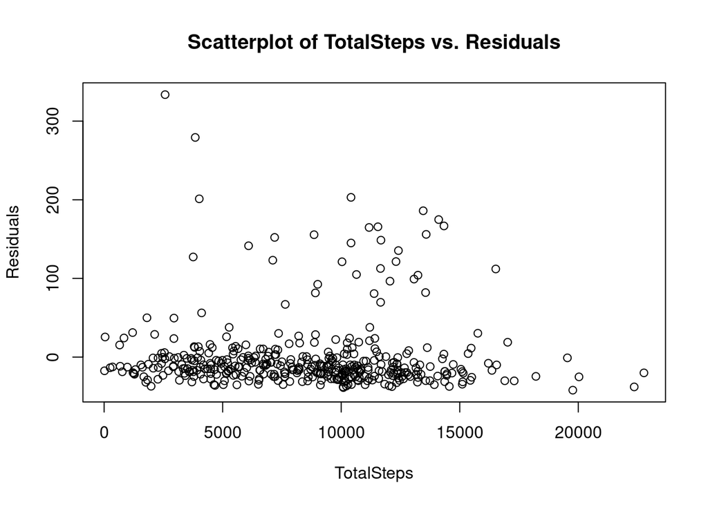

```r
#Assumptions Check

#1. Linearity
# Scatterplot for Linearity Check
plot(daily_data$TotalSteps, lm_totalSteps_latency$residuals,
     xlab = "TotalSteps", ylab = "Residuals",
     main = "Scatterplot of TotalSteps vs. Residuals")
```

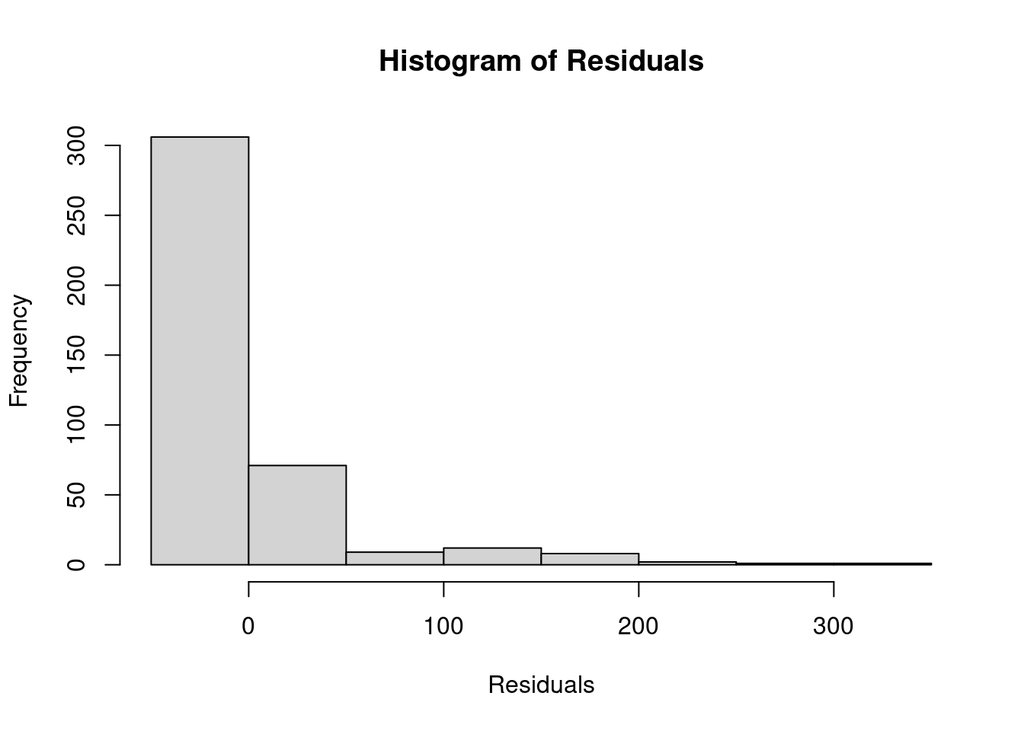

```r
#2. Normality of Residuals
# Histogram for Normality of Residuals Check
hist(lm_totalSteps_latency$residuals,
     xlab = "Residuals", ylab = "Frequency",
     main = "Histogram of Residuals")
```

```r
#3. Homoscedasticity
# Perform Breusch-Pagan test for Homoscedasticity
library(lmtest)
homoscedasticity_test_totalSteps_latency <- bptest(lm_totalSteps_latency)
print(homoscedasticity_test_totalSteps_latency)
```

```
##
##  studentized Breusch-Pagan test
##
## data:  lm_totalSteps_latency
## BP = 0.055101, df = 1, p-value = 0.8144
```

```r
#4. Independence of Residuals
# Perform Durbin-Watson test for Independence of Residuals
durbin_watson_test_totalSteps_latency <- dwtest(lm_totalSteps_latency)
print(durbin_watson_test_totalSteps_latency)
```

```
##
##  Durbin-Watson test
##
## data:  lm_totalSteps_latency
## DW = 0.56772, p-value < 2.2e-16
## alternative hypothesis: true autocorrelation is greater than 0
```

## Influence of Activity (Total Steps) on Sleep Duration

### Model 2 Fitting (TotalMinutesAsleep ~ TotalSteps)

```r
# Fit a linear regression model
lm_totalSteps_duration <- lm(TotalMinutesAsleep ~ TotalSteps, data = daily_data)

#Model Summary

# Summarize the model
summary(lm_totalSteps_duration)
```

```
##
## Call:
## lm(formula = TotalMinutesAsleep ~ TotalSteps, data = daily_data)
##
## Residuals:
##     Min      1Q  Median      3Q     Max
## -386.32  -56.67   13.31   70.32  350.99
##
## Coefficients:
##               Estimate Std. Error t value Pr(>|t|)
## (Intercept) 465.423623  13.138907  35.423  < 2e-16 ***
## TotalSteps   -0.005432   0.001387  -3.916 0.000105 ***
## ---
## Signif. codes:  0 '***' 0.001 '**' 0.01 '*' 0.05 '.' 0.1 ' ' 1
##
## Residual standard error: 116.6 on 408 degrees of freedom
## Multiple R-squared:  0.03623,    Adjusted R-squared:  0.03387
## F-statistic: 15.34 on 1 and 408 DF,  p-value: 0.0001054
```

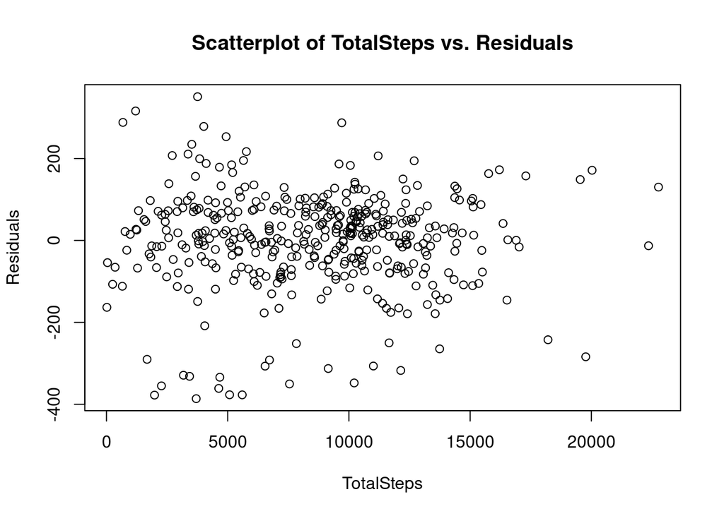

```r
# 1. Scatterplot for Linearity Check
plot(daily_data$TotalSteps, lm_totalSteps_duration$residuals,
     xlab = "TotalSteps", ylab = "Residuals",
     main = "Scatterplot of TotalSteps vs. Residuals")
```

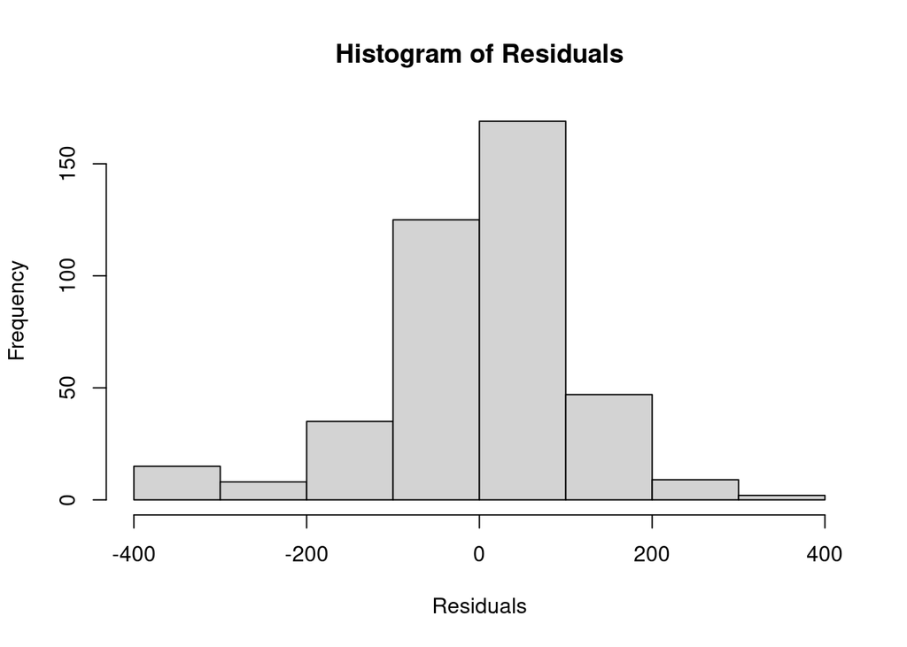

```r
# 2. Normality of Residuals
# Histogram for Normality of Residuals Check
hist(lm_totalSteps_duration$residuals,
     xlab = "Residuals", ylab = "Frequency",
     main = "Histogram of Residuals")
```

```r
# Perform Shapiro-Wilk test for Normality of Residuals
shapiro_test_totalSteps_duration <- shapiro.test(lm_totalSteps_duration$residuals)
print(shapiro_test_totalSteps_duration)
```

```
##
##  Shapiro-Wilk normality test
##
## data:  lm_totalSteps_duration$residuals
## W = 0.94647, p-value = 5.187e-11
```

```r
# 3. Homoscedasticity Check
# Perform Breusch-Pagan test for Homoscedasticity
homoscedasticity_test_totalSteps_duration <- bptest(lm_totalSteps_duration)
print(homoscedasticity_test_totalSteps_duration)
```

```
##
##  studentized Breusch-Pagan test
##
## data:  lm_totalSteps_duration
## BP = 5.8424, df = 1, p-value = 0.01564
```

```r
# 4. Independence of Residuals
# Perform Durbin-Watson test for Independence of Residuals
durbin_watson_test_totalSteps_duration <- dwtest(lm_totalSteps_duration)
print(durbin_watson_test_totalSteps_duration)
```

```
##
##  Durbin-Watson test
##
## data:  lm_totalSteps_duration
## DW = 1.6195, p-value = 5.175e-05
## alternative hypothesis: true autocorrelation is greater than 0
```

## Influence of Acitivty (composite score) on Sleep Latency

### Model 3 Fitting (sleep_latency ~ activeMinutes)

A decision has been made to construct a composite variable named ‘activity’ by utilizing a composite score derived from the standard MET ranges. This variable amalgamates multiple aspects of activity for enhanced analysis.

**Composite Score for Activity Intensity**

A composite score is calculated based on MET values (energy expenditure) for different activity levels. Weights are assigned to each activity level to reflect their importance in assessing intensity:

- **Very Active** (Weight: 0.5): High-intensity activities (e.g., running)
- **Fairly Active** (Weight: 0.3): Moderate-intensity activities (e.g., brisk walking)
- **Lightly Active** (Weight: 0.2): Low-intensity activities (e.g., light housework)

The weights were chosen to reflect the relative importance of each activity level in assessing overall activity intensity.

```r
# Define weights based on MET ranges
composite_score_weights <- c(weights <- c(0.5, 0.3, 0.2))  # VeryActive: 0.5, FairlyActive: 0.3, LightlyActive: 0.2

# Create the composite score (activeMinutes)
daily_data$activeMinutes <-
  daily_data$VeryActiveMinutes * weights[1] +
  daily_data$FairlyActiveMinutes * weights[2] +
  daily_data$LightlyActiveMinutes * weights[3]

#Fit a linear regression model
lm_activity_latency <- lm(sleep_latency ~ activeMinutes, data = daily_data)

# Summarize the model
summary(lm_activity_latency)
```

```
##
## Call:
## lm(formula = sleep_latency ~ activeMinutes, data = daily_data)
##
## Residuals:
##    Min     1Q Median     3Q    Max
## -40.84 -22.50 -13.02   0.47 325.77
##
## Coefficients:
##               Estimate Std. Error t value Pr(>|t|)
## (Intercept)   47.52956    6.12266   7.763 6.75e-14 ***
## activeMinutes -0.13429    0.09268  -1.449    0.148
## ---
## Signif. codes:  0 '***' 0.001 '**' 0.01 '*' 0.05 '.' 0.1 ' ' 1
##
## Residual standard error: 46.65 on 408 degrees of freedom
## Multiple R-squared:  0.00512,    Adjusted R-squared:  0.002681
## F-statistic:   2.1 on 1 and 408 DF,  p-value: 0.1481
```

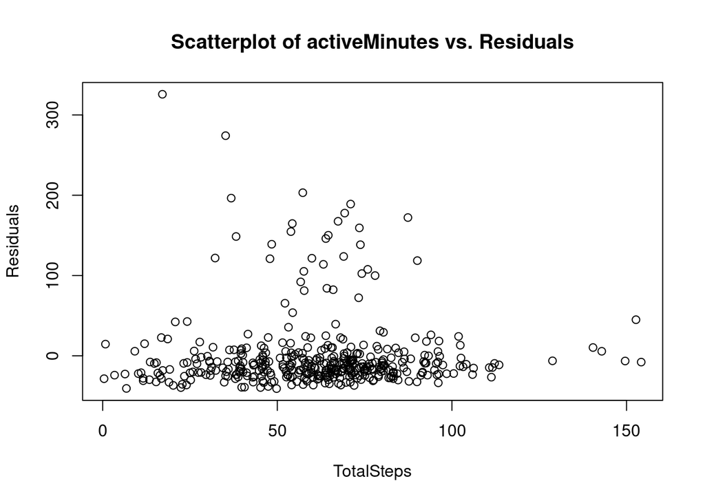

```r
#1.Scatterplot for Linearity Check
plot(daily_data$activeMinutes, lm_activity_latency$residuals,
     xlab = "TotalSteps", ylab = "Residuals",
     main = "Scatterplot of activeMinutes vs. Residuals")
```

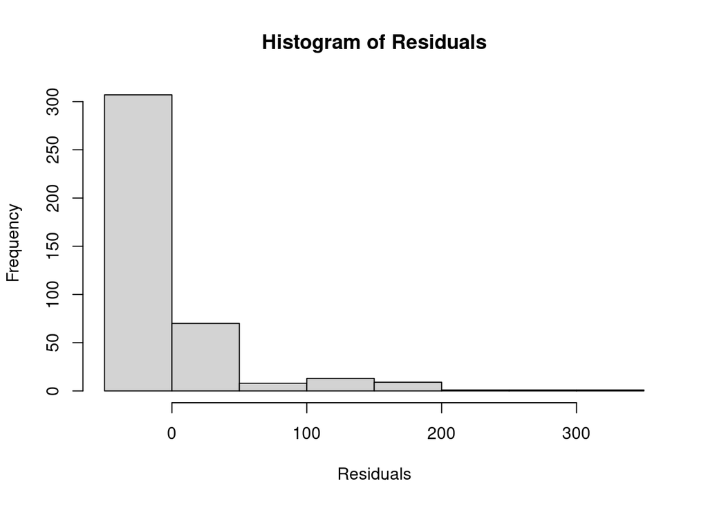

```r
#2.Histogram for Normality of Residuals Check
hist(lm_activity_latency$residuals,
     xlab = "Residuals", ylab = "Frequency",
     main = "Histogram of Residuals")
```

```r
#3. Homoscedasticity Check
# Perform Breusch-Pagan test for Homoscedasticity
homoscedasticity_test_activity_latency <- bptest(lm_activity_latency)
print(homoscedasticity_test_activity_latency)
```

```
##
##  studentized Breusch-Pagan test
##
## data:  lm_activity_latency
## BP = 2.6823, df = 1, p-value = 0.1015
```

```r
# 4.Perform Durbin-Watson test for Independence of Residuals
durbin_watson_test_activity_latency <- dwtest(lm_activity_latency)
print(durbin_watson_test_activity_latency)
```

```
##
##  Durbin-Watson test
##
## data:  lm_activity_latency
## DW = 0.56649, p-value < 2.2e-16
## alternative hypothesis: true autocorrelation is greater than 0
```

## Influence of Activity (Composite Score) on Sleep Duration

### Model 4 Fitting (TotalMinutesAsleep ~ activeMinutes)

```r
#Fit a linear regression model
lm_activity_duration <- lm(TotalMinutesAsleep ~ activeMinutes, data = daily_data)

# Summarize the model
summary(lm_activity_duration)
```

```
##
## Call:
## lm(formula = TotalMinutesAsleep ~ activeMinutes, data = daily_data)
##
## Residuals:
##     Min      1Q  Median      3Q     Max
## -389.28  -54.42   12.10   73.38  361.31
##
## Coefficients:
##               Estimate Std. Error t value Pr(>|t|)
## (Intercept)   451.9227    15.4917  29.172   <2e-16 ***
## activeMinutes  -0.5350     0.2345  -2.282    0.023 *
## ---
## Signif. codes:  0 '***' 0.001 '**' 0.01 '*' 0.05 '.' 0.1 ' ' 1
##
## Residual standard error: 118 on 408 degrees of freedom
## Multiple R-squared:  0.0126, Adjusted R-squared:  0.01018
## F-statistic: 5.206 on 1 and 408 DF,  p-value: 0.02302
```

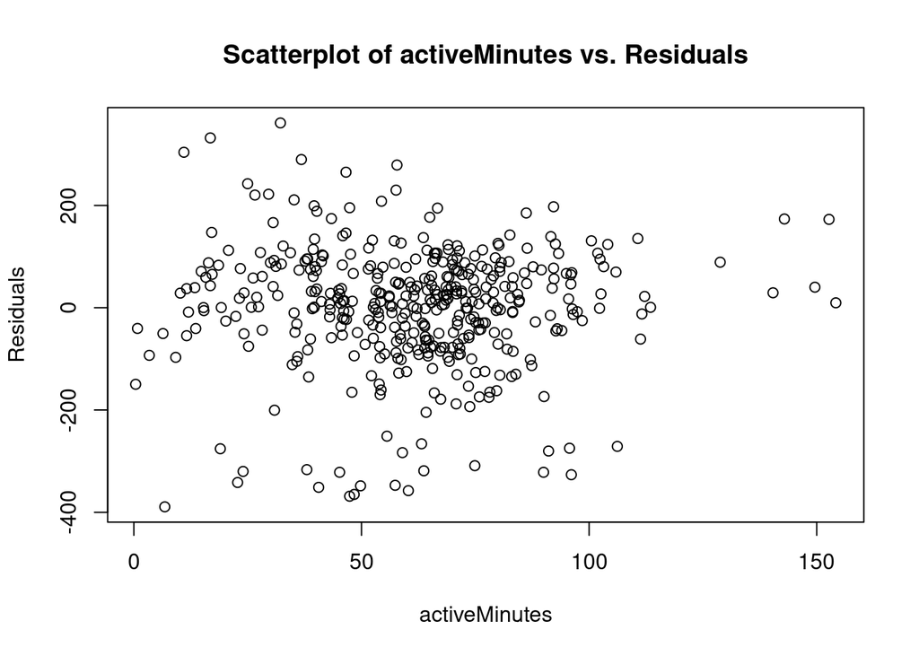

```r
#1.Scatterplot for Linearity Check
plot(daily_data$activeMinutes, lm_activity_duration$residuals,
     xlab = "activeMinutes", ylab = "Residuals",
     main = "Scatterplot of activeMinutes vs. Residuals")
```

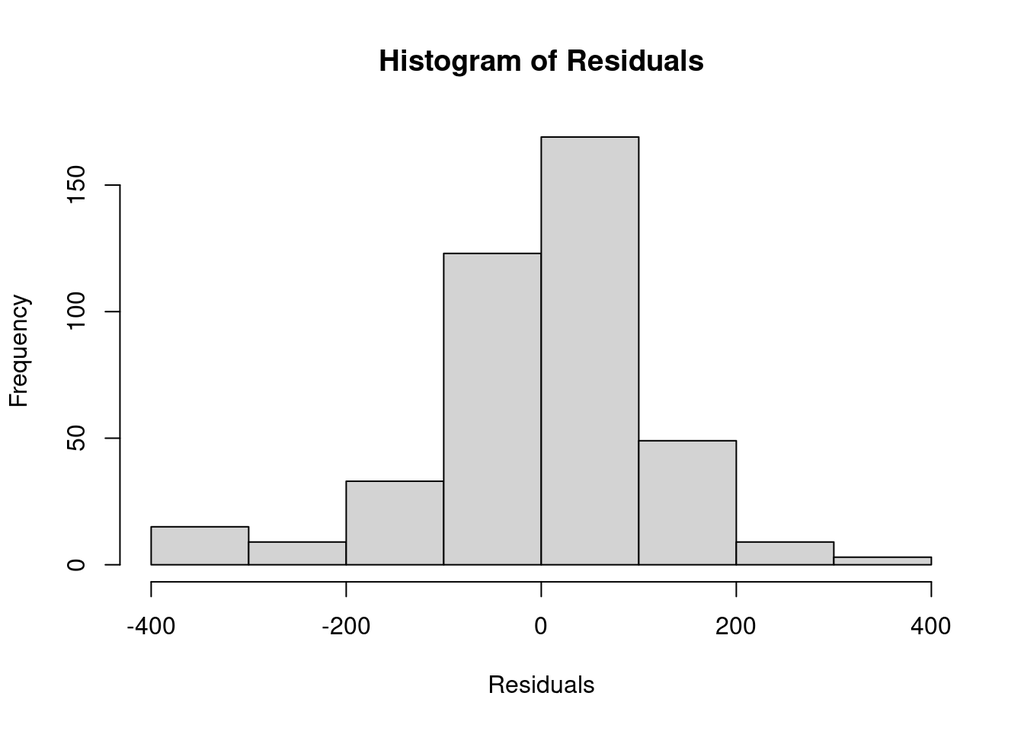

```r
#2.Histogram for Normality of Residuals Check
hist(lm_activity_duration$residuals,
     xlab = "Residuals", ylab = "Frequency",
     main = "Histogram of Residuals")
```

```r
# Perform Shapiro-Wilk test for Normality of Residuals
shapiro_test_activity_duration <- shapiro.test(lm_activity_duration$residuals)
print(shapiro_test_activity_duration)
```

```
##
##  Shapiro-Wilk normality test
##
## data:  lm_activity_duration$residuals
## W = 0.95077, p-value = 1.901e-10
```

```r
#3. Homoscedasticity Check
# Perform Breusch-Pagan test for Homoscedasticity
homoscedasticity_test_activity_duration <- bptest(lm_activity_duration)
print(homoscedasticity_test_activity_duration)
```

```
##
##  studentized Breusch-Pagan test
##
## data:  lm_activity_duration
## BP = 5.8881, df = 1, p-value = 0.01524
```

```r
# 4.Perform Durbin-Watson test for Independence of Residuals
durbin_watson_test_activity_duration <- dwtest(lm_activity_duration)
print(durbin_watson_test_activity_duration)
```

```
##
##  Durbin-Watson test
##
## data:  lm_activity_duration
## DW = 1.5928, p-value = 1.665e-05
## alternative hypothesis: true autocorrelation is greater than 0
```

## Influence of Sedentary Minutes on Sleep Latency

### Model 5 Fitting (sleep_latency ~ SedentaryMinutes)

```r
#Fit a linear regression model
lm_sedentary_latency <- lm(sleep_latency ~ SedentaryMinutes, data = daily_data)
# Summarize the model
summary(lm_sedentary_latency)
```

```
##
## Call:
## lm(formula = sleep_latency ~ SedentaryMinutes, data = daily_data)
##
## Residuals:
##    Min     1Q Median     3Q    Max
## -53.52 -21.77 -12.03  -0.46 325.76
##
## Coefficients:
##                  Estimate Std. Error t value Pr(>|t|)
## (Intercept)      72.51550   10.03414   7.227 2.45e-12 ***
## SedentaryMinutes -0.04663    0.01372  -3.398 0.000746 ***
## ---
## Signif. codes:  0 '***' 0.001 '**' 0.01 '*' 0.05 '.' 0.1 ' ' 1
##
## Residual standard error: 46.12 on 408 degrees of freedom
## Multiple R-squared:  0.02752,    Adjusted R-squared:  0.02514
## F-statistic: 11.55 on 1 and 408 DF,  p-value: 0.0007456
```

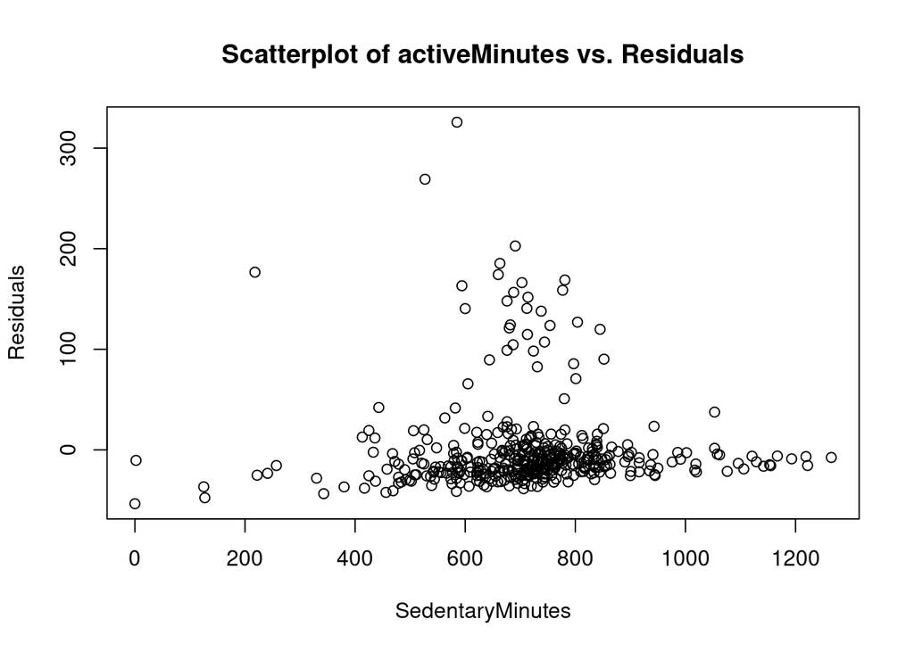

```r
#1.Scatterplot for Linearity Check
plot(daily_data$SedentaryMinutes, lm_sedentary_latency$residuals,
     xlab = "SedentaryMinutes", ylab = "Residuals",
     main = "Scatterplot of activeMinutes vs. Residuals")
```

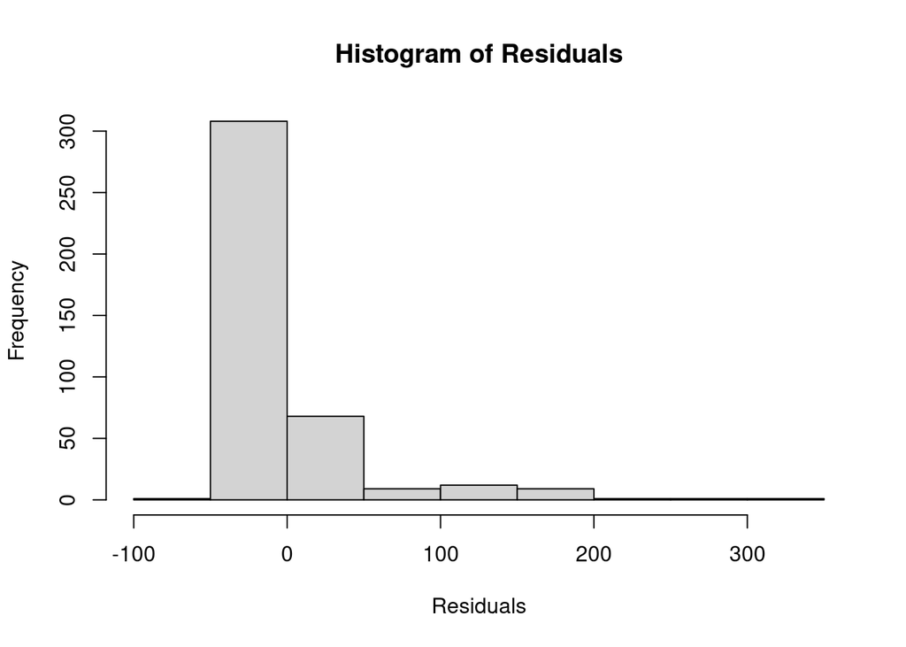

```r
#2.Histogram for Normality of Residuals Check
hist(lm_sedentary_latency$residuals,
     xlab = "Residuals", ylab = "Frequency",
     main = "Histogram of Residuals")
```

```r
#3. Homoscedasticity Check
# Perform Breusch-Pagan test for Homoscedasticity
homoscedasticity_test_sedentary_latency <- bptest(lm_sedentary_latency)
print(homoscedasticity_test_sedentary_latency)
```

```
##
##  studentized Breusch-Pagan test
##
## data:  lm_sedentary_latency
## BP = 4.0771, df = 1, p-value = 0.04347
```

```r
# 4.Perform Durbin-Watson test for Independence of Residuals
durbin_watson_test_sedentary_latency <- dwtest(lm_sedentary_latency)
print(durbin_watson_test_sedentary_latency)
```

```
##
##  Durbin-Watson test
##
## data:  lm_sedentary_latency
## DW = 0.56574, p-value < 2.2e-16
## alternative hypothesis: true autocorrelation is greater than 0
```

## Influence of Sedentary Minutes on Sleep Duration

### Model 6 Fitting (TotalMinutesAsleep ~ SedentaryMinutes)

```r
#Fit a linear regression model
lm_sedentary_duration <- lm(TotalMinutesAsleep ~ SedentaryMinutes, data = daily_data)

# Summarize the model
summary(lm_sedentary_duration)
```

```
##
## Call:
## lm(formula = TotalMinutesAsleep ~ SedentaryMinutes, data = daily_data)
##
## Residuals:
##     Min      1Q  Median      3Q     Max
## -422.74  -50.04    8.05   57.68  363.91
##
## Coefficients:
##                   Estimate Std. Error t value Pr(>|t|)
## (Intercept)      724.74079   20.65331   35.09   <2e-16 ***
## SedentaryMinutes  -0.42911    0.02825  -15.19   <2e-16 ***
## ---
## Signif. codes:  0 '***' 0.001 '**' 0.01 '*' 0.05 '.' 0.1 ' ' 1
##
## Residual standard error: 94.93 on 408 degrees of freedom
## Multiple R-squared:  0.3613, Adjusted R-squared:  0.3597
## F-statistic: 230.8 on 1 and 408 DF,  p-value: < 2.2e-16
```

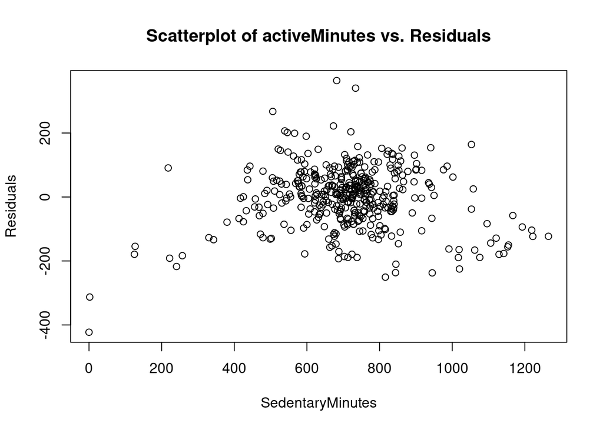

```r
#1.Scatterplot for Linearity Check
plot(daily_data$SedentaryMinutes, lm_sedentary_duration$residuals,
     xlab = "SedentaryMinutes", ylab = "Residuals",
     main = "Scatterplot of activeMinutes vs. Residuals")
```

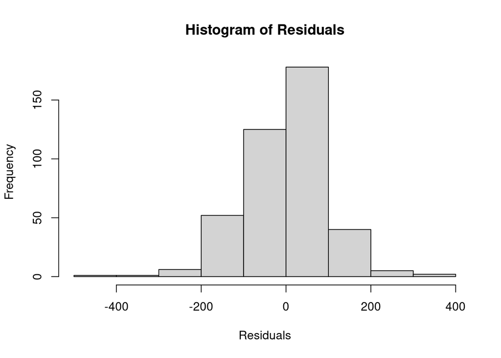

```r
#2.Histogram for Normality of Residuals Check
hist(lm_sedentary_duration$residuals,
     xlab = "Residuals", ylab = "Frequency",
     main = "Histogram of Residuals")
```

```r
# Perform Shapiro-Wilk test for Normality of Residuals
shapiro_test_sedentary_duration <- shapiro.test(lm_sedentary_duration$residuals)
print(shapiro_test_sedentary_duration)
```

```
##
##  Shapiro-Wilk normality test
##
## data:  lm_sedentary_duration$residuals
## W = 0.98008, p-value = 2.011e-05
```

```r
#3. Homoscedasticity Check

# Perform Breusch-Pagan test for Homoscedasticity
homoscedasticity_test_sedentary_duration <- bptest(lm_sedentary_duration)
print(homoscedasticity_test_sedentary_duration)
```

```
##
##  studentized Breusch-Pagan test
##
## data:  lm_sedentary_duration
## BP = 6.5474, df = 1, p-value = 0.0105
```

```r
# 4.Perform Durbin-Watson test for Independence of Residuals
durbin_watson_test_sedentary_duration<- dwtest(lm_sedentary_duration)
print(durbin_watson_test_sedentary_duration)
```

```
##
##  Durbin-Watson test
##
## data:  lm_sedentary_duration
## DW = 1.6199, p-value = 5.555e-05
## alternative hypothesis: true autocorrelation is greater than 0
```

# Model 6 (TotalMinutesAsleep ~ SedentaryMinutes)

## Addressing Model Shortcomings

### Addressing Heteroskedasticity with Robust Regression

To mitigate the issue of heteroskedasticity while preserving the interpretability associated with Ordinary Least Squares (OLS), the choice is made to employ a robust regression model. This approach enhances the robustness of the analysis.

**Implementing Robust Regression**

```r
# Install and load robustbase package
install.packages("robustbase")
library(robustbase)

# Fit a robust regression model
robust_model_sedentary_duration <- lmrob(TotalMinutesAsleep ~ SedentaryMinutes, data = daily_data)

# Summarize the robust regression model
summary(robust_model_sedentary_duration)
```

```
##
## Call:
## lmrob(formula = TotalMinutesAsleep ~ SedentaryMinutes, data = daily_data)
##  \--> method = "MM"
## Residuals:
##      Min       1Q   Median       3Q      Max
## -469.926  -54.665    4.165   54.605  358.617
##
## Coefficients:
##                   Estimate Std. Error t value Pr(>|t|)
## (Intercept)      771.92607   38.92231  19.832   <2e-16 ***
## SedentaryMinutes  -0.49053    0.05412  -9.064   <2e-16 ***
## ---
## Signif. codes:  0 '***' 0.001 '**' 0.01 '*' 0.05 '.' 0.1 ' ' 1
##
## Robust residual standard error: 82.49
## Multiple R-squared:  0.4256, Adjusted R-squared:  0.4242
## Convergence in 17 IRWLS iterations
##
## Robustness weights:
##  observation 143 is an outlier with |weight| = 0 ( < 0.00024);
##  41 weights are ~= 1. The remaining 368 ones are summarized as
##    Min. 1st Qu.  Median    Mean 3rd Qu.    Max.
## 0.01757 0.85240 0.95010 0.88750 0.98620 0.99900
## Algorithmic parameters:
##        tuning.chi                bb        tuning.psi        refine.tol
##         1.548e+00         5.000e-01         4.685e+00         1.000e-07
##           rel.tol         scale.tol         solve.tol          zero.tol
##         1.000e-07         1.000e-10         1.000e-07         1.000e-10
##       eps.outlier             eps.x warn.limit.reject warn.limit.meanrw
##         2.439e-04         2.301e-09         5.000e-01         5.000e-01
##      nResample         max.it       best.r.s       k.fast.s          k.max
##            500             50              2              1            200
##    maxit.scale      trace.lev            mts     compute.rd fast.s.large.n
##            200              0           1000              0           2000
##                   psi           subsampling                   cov
##            "bisquare"         "nonsingular"         ".vcov.avar1"
## compute.outlier.stats
##                  "SM"
## seed : int(0)
```

**Examining Autocorrelation in the Robust Model**

Although addressing autocorrelation is not typically a primary concern in linear regression models, particularly with cross-sectional data, our initial analysis hinted at potential autocorrelation. Subsequently, we will assess the robust model to ascertain whether this concern has been effectively addressed.

```r
# Extract and analyze residuals for autocorrelation
residuals_robust_sedentary_duration <- residuals(robust_model_sedentary_duration)
n <- length(residuals_robust_sedentary_duration)
d <- sum(diff(residuals_robust_sedentary_duration)^2)
durbin_watson_statistic <- d / sum(residuals_robust_sedentary_duration^2)

# Check for autocorrelation
if (durbin_watson_statistic < 1.5) {
  cat("Positive autocorrelation detected.\n")
} else if (durbin_watson_statistic > 2.5) {
  cat("Negative autocorrelation detected.\n")
} else {
  cat("No significant autocorrelation detected.\n")
}
```

```
## No significant autocorrelation detected.
```

```r
# Display the Durbin-Watson statistic
durbin_watson_statistic
```

```
## [1] 1.632924
```

**Visualizing the Robust Regression Model**

Utilizing a scatterplot with a robust regression line, we aim to visually depict the relationship between Sedentary Minutes and Total Minutes Asleep, providing a clear and intuitive representation of their correlation.

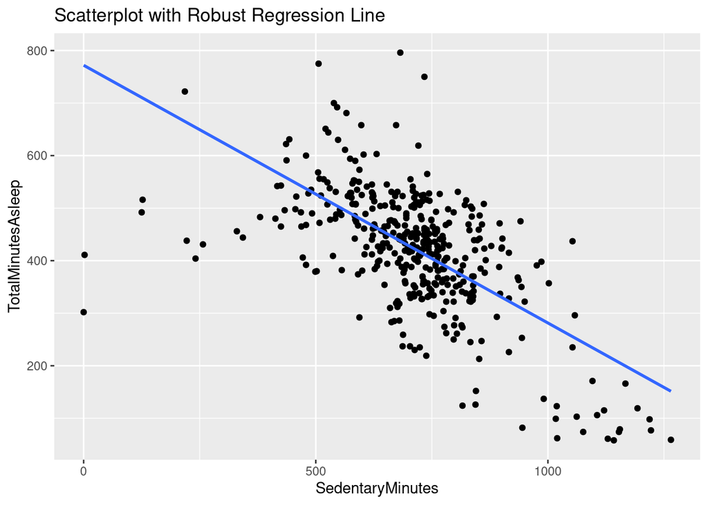

```r
# Create a scatterplot with a robust regression line
library(ggplot2)
ggplot(daily_data, aes(x = SedentaryMinutes, y = TotalMinutesAsleep)) +
  geom_point() +
  geom_smooth(method = "lmrob", formula = y ~ x, se = FALSE) +
  labs(x = "SedentaryMinutes", y = "TotalMinutesAsleep") +
  ggtitle("Scatterplot with Robust Regression Line")
```

# **SHARE**

**Plotting Hourly Activity**

The visualization of average steps taken per hour enables the identification of peak activity periods throughout the day, providing valuable insights into user behavior and helping inform potential marketing and product strategies.

The data presents a distinct biphasic pattern in daily activity, with two major peaks observed in users’ step counts. The first significant surge occurs between 12:00 and 14:00, possibly reflecting lunchtime walks or midday exercise breaks. A second notable peak is seen from 17:00 to 19:00, aligning with evening routines or post-work activity sessions. Outside of these windows, particularly after 19:00, there is a marked decrease in physical activity, suggesting that users may be less motivated to engage in exercise during the late evening hours.

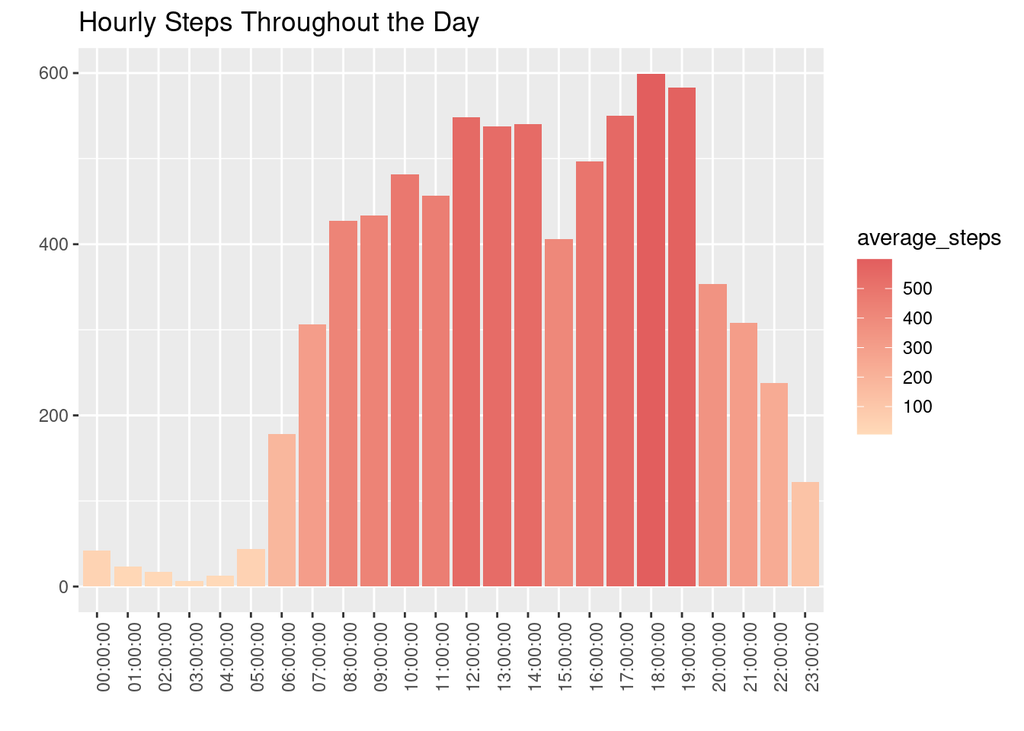

```r
# Plot average steps per hour
hourlySteps %>%
  group_by(time) %>%
  summarize(average_steps = mean(StepTotal)) %>%
  ggplot() +
  geom_col(mapping = aes(x=time, y = average_steps, fill = average_steps)) +
  labs(title = "Hourly Steps Throughout the Day", x="", y="") +
  scale_fill_gradient(low = "#FFDAB9", high = "#E25E5E") +
  theme(axis.text.x = element_text(angle = 90))
```

**The Pie Chart: Usage Category Proportions**

This pie chart is a visual representation of user engagement levels, with “High Usage” at 76%, “Moderate Usage” at 21%, and “Low Usage” at 3%. The percentages shown within each segment represent the proportion of users in that category relative to the total number of users in all categories, facilitating a quick assessment of user distribution among various activity categories.

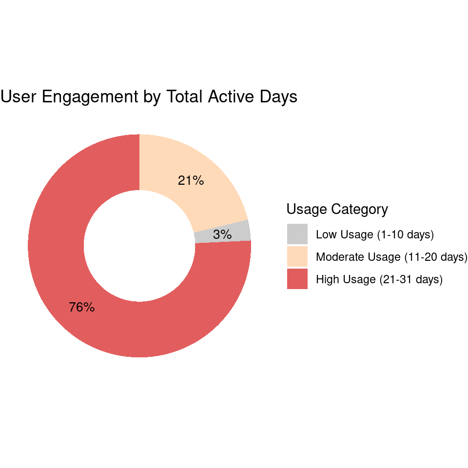

```r
# Calculate the midpoint of each slice
active_days_summary <- active_days_summary %>%
  arrange(desc(usage_category)) %>%
  mutate(lag_count = lag(cumsum(count), default = 0),
         cum_count = cumsum(count),
         mid_point = (lag_count + cum_count) / 2)
# Create a Donut Chart
ggplot(active_days_summary, aes(x = 2, y = count, fill = usage_category)) +
  geom_bar(stat = "identity", width = 1) +
  coord_polar("y", start = 0) +
  theme_void() +
  labs(title = "User Engagement by Total Active Days",
       fill = "Usage Category") +
  scale_fill_manual(
    values = c(
      "low usage" = "gray80",
      "moderate usage" = "#FFDAB9",
      "high usage" = "#E25E5E"
    ),
    breaks = c("low usage", "moderate usage", "high usage"),
    labels = c("Low Usage (1-10 days)", "Moderate Usage (11-20 days)", "High Usage (21-31 days)")
  ) +
  geom_text(aes(label = scales::percent(count/sum(count)), y = mid_point), color = "black", size = 3.5) +
  xlim(c(0.5, 2.5)) # Create the donut hole
```

**Sleep Latency Visualization with Pie Chart**

The pie chart shows the proportions of users by sleep latency duration. A significant majority, 66.7%, have a sleep latency of more than 20 minutes. 20.8% of users fall into the 10-20 minute latency category, while 12.5% experience sleep latency of less than 10 minutes.

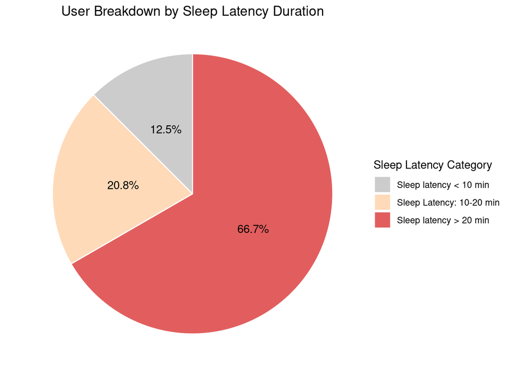

```r
# Install and load necessary package for pie chart
install.packages("scales")
library(scales)

#Set the factor levels of the Category variable
sleep_latency$Category <- factor(sleep_latency$Category, levels = c(
  "Sleep latency < 10 min",
  "Sleep Latency: 10-20 min",
  "Sleep latency > 20 min",
  "Undefined Category"
))
# Create a pie chart for sleep latency
ggplot(sleep_latency, aes(x = "", y = Count, fill = Category)) +
  geom_bar(width = 1, color = "white", stat = "identity") +
  coord_polar("y") +
  labs(title = "User Breakdown by Sleep Latency Duration", fill = "Sleep Latency Category") +
  theme_void() +
  scale_fill_manual(values = c(
    "Sleep latency < 10 min" = "gray80",
    "Sleep Latency: 10-20 min" = "#FFDAB9",
    "Sleep latency > 20 min" = "#E25E5E",
    "Undefined Category" = "#808080"
  )) +
  geom_text(aes(label = percent(Count/sum(Count))), position = position_stack(vjust = 0.5)) +
  theme(plot.title = element_text(hjust = 0.5))
```

**Total Sleep Duration Visualization with Histogram**

A histogram is employed to visually represent the distribution of total sleep duration, providing a clear and concise overview of sleep duration patterns.

This histogram illustrates the frequency of different sleep duration among participants, divided into two categories: less than 7 hours and 7 hours or more. It’s important to note that this graph does not show mutually exclusive data. Some participants appear in both categories because they have nights where they sleep for less than 7 hours and others for 7 or more. Therefore, while it may seem that a larger number of instances are in the ‘≥ 7 hours’ category, suggesting a healthier sleep pattern, this view does not account for individual variability across different nights.

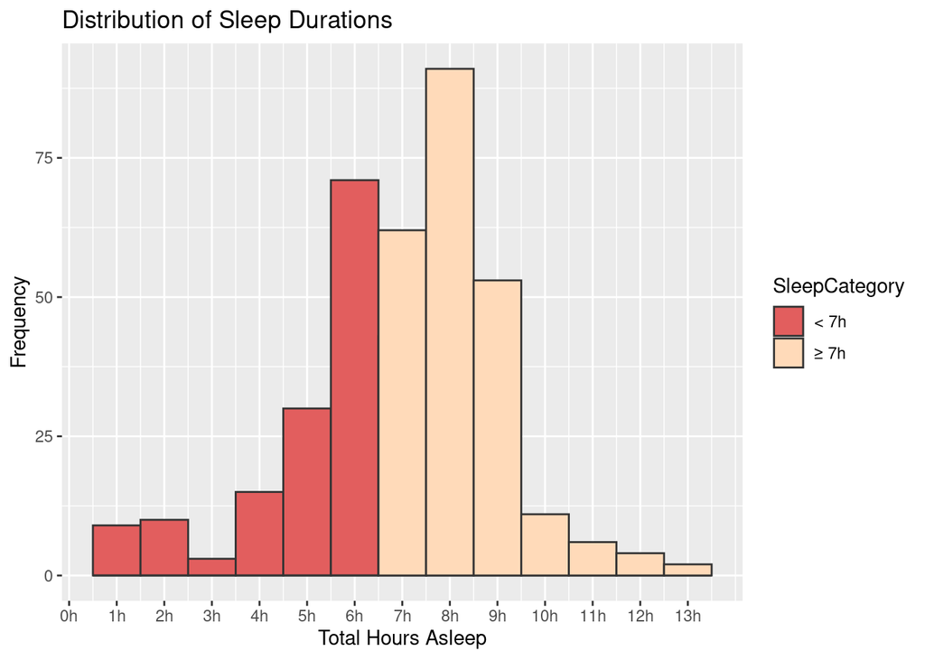

```r
# Install and load necessary package for color gradients
install.packages("viridis")
library(viridis)

dailySleep <- dailySleep %>%
  mutate(SleepCategory = case_when(
    TotalMinutesAsleep < 420 ~ "< 7h",
    TotalMinutesAsleep >= 420 ~ "≥ 7h",
    TRUE ~ "Other"
  ))

# Create a histogram for total sleep duration
ggplot(dailySleep, aes(x = TotalMinutesAsleep/60, fill = SleepCategory)) +
  geom_histogram(binwidth = 1, position = "identity", color = "#333333") +
  labs(title = "Distribution of Sleep Durations", x = "Total Hours Asleep", y = "Frequency") +
  scale_x_continuous(labels = scales::number_format(scale = 1, suffix = "h"), breaks = seq(0, max(dailySleep$TotalMinutesAsleep/60), by = 1)) +
  scale_fill_manual(values = c("< 7h" = "#E25E5E", "≥ 7h" = "#FFDAB9"))
```

**Total Sleep Duration Visualization with Pie Chart**

Another pie chart is generated to depict the proportion of individuals attaining sufficient sleep, allowing for a straightforward visualization of this specific aspect of sleep patterns.

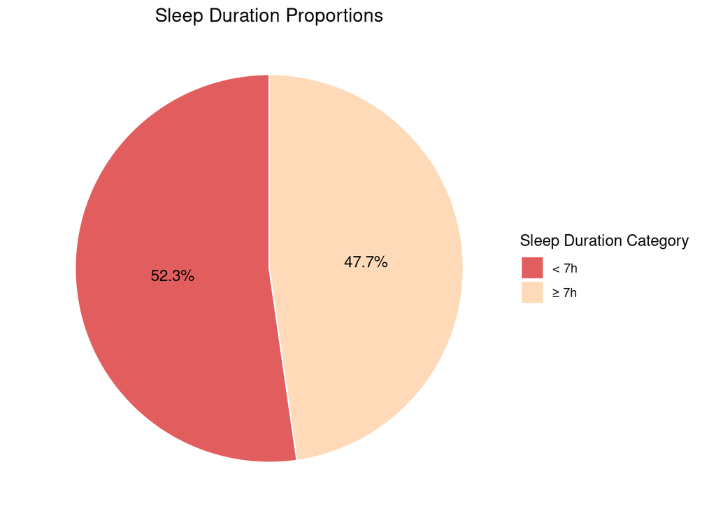

```r
# Create a pie chart for sleep duration
ggplot(total_sleep, aes(x = "", y = Count, fill = SleepCategory)) +
  geom_bar(width = 1, color = "white", stat = "identity") +
  coord_polar("y") +
  labs(title = "Sleep Duration Proportions", fill = "Sleep Duration Category") +
  theme_void() +
  scale_fill_manual(values = c(
    "< 7h" = "#E25E5E",
    "≥ 7h" = "#FFDAB9",
    "Other" = "gray80"
  )) +
  geom_text(aes(label = percent(Count/sum(Count))), position = position_stack(vjust = 0.5)) +
  theme(plot.title = element_text(hjust = 0.5))
```

**Conclusion**

The analysis reveals complex and individual variability in sleep patterns. It was observed that a substantial segment of the population achieves less than the recommended 7 hours of sleep, with approximately half of the recorded instances falling short of this benchmark. Additionally, a significant majority exhibit sleep latency over 20 minutes, pointing to prevalent sleep quality concerns. These insights underscore the necessity of implementing targeted measures to promote better sleep hygiene and extend sleep duration. Further sections will delineate comprehensive recommendations, advancing data-driven approaches to improve sleep health in the context of organizational well-being.

# Recommendations for Stakeholders

### User Engagement & Usage

- **Loyalty Programs for High Usage**: Develop exclusive features or loyalty rewards for the 76% highly engaged users to sustain their interest.
- **Targeted Upselling**: Offer premium services to the ‘High Usage’ group, capitalizing on their commitment.
- **Enhancing Moderate Usage Engagement**: Identify barriers for the 21% ‘Moderate Usage’ group and address them with product improvements or tailored marketing.
- **Understanding Low Usage**: Investigate the reasons behind the 3% ‘Low Usage’ group’s limited engagement for targeted interventions.
- **Retention and Growth**: Focus on maintaining high user engagement and transitioning ‘Moderate’ users to ‘High Usage’.
- **Feedback-Informed Product Development**: Encourage user feedback across all segments for continuous product enhancement.

### Sleep Latency and Health

- **Products for Sleep Initiation**: Develop solutions for the 66.7% with extended sleep latency, like relaxation aids or educational content on sleep hygiene.
- **Moderate Sleep Latency Interventions**: Offer guidance or light sleep aids to the 20.8% with 10-20 minute sleep latency.
- **Sharing Best Practices**: Utilize insights from the 12.5% with quick sleep onset to educate others.
- **Personalized Sleep Features**: Implement advanced sleep tracking with personalized goals and educational content.
- **Relaxation Tools**: Include guided meditation and calming soundscapes for better sleep preparation.
- **Sleep and Activity Analytics**: Offer analytics on the correlation between physical activity and sleep quality.

### Communication & Motivation

- **Customized Messaging**: Use motivational and data-driven messages to encourage active lifestyle choices and highlight their sleep benefits.

### Motivational Messaging with Quantitative Impact

[output not shown]